# Li-YouTubePurchaseUsageEffectsDraft-2025-MKSC.pdf

Converted from PDF `Li-YouTubePurchaseUsageEffectsDraft-2025-MKSC.pdf` · 60 pages · anchors: page `#pN`, block `#pN-bK`

Page 1

## Opposing Influences of YouTube Influencers: Purchase

## and Usage Effects in the Video Game Industry*

#### Nan Li†, Avery Haviv‡and Mitch Lovett<sup>§</sup>

#### March 8, 2024

#### **Abstract**

Influencers promote firms’ products by posting content such as videos on social media platforms. For entertainment products, these posts could substitute or complement demand for the original entertainment product. We study video games, the largest entertainment product category comprising 1/3 of YouTube traffic, using a large daily panel data set on thousands of video games. Leveraging a supply shock on YouTube called the “Adpocalypse”, we measure the impact of influencer videos on purchase and usage of games. We provide evidence that on average influencer video posts substitute to video games for purchases but complement for usage. We also find that influencer effects differ across firms. Managers can use these results to align the influencer effects they face with their revenue models, such as using in-game purchases or a subscription model when facing complements on usage. *Keywords:* Influencer marketing, Natural experiment, YouTube, Video games, Adpocolapse

*Part of this paper was previously circulated under the title ”The Effect of Extending and Sharing Intellectual Property Rights” and ”Digital Marketing and Intellectual Property Rights: Leveraging Events and Influencers”. We thank the participants of seminars at Tongji University, Shanghai University of Economics and Finance, Xiamen University, 2019 Marketing Dynamic conference, London Business School, 2023 China Marketing International Conference, and 2023 ZEW conference on ICT for helpful comments and feedback. †Assistant Professor of Marketing, Advanced Institute of Business, School of Economics and Management, Tongji University

‡Associate Professor of Marketing, Simon Business School, University of Rochester §Professor of Marketing, Simon Business School, University of Rochester

1

Electronic copy available at: https://ssrn.com/abstract=3884038

Page 2

### **1 Introduction**

Social media and online video platforms have heralded bold new marketing strategies, chief among

them leveraging outside content creators who post videos or other content to social media that

showcase or promote products. The use of such influencer strategies is rapidly growing with a

ten-fold increase in worldwide spending since 2016 to 16.4 billion (in US dollars) and represents

a critical component of many marketing strategies today with more than 90% of firms reporting

spending more than 10% of their marketing budgets on influencer marketing tactics.<sup>1</sup> Our context,

wherein influencers exhibit video-game footage on YouTube, accounts for one-third of YouTube’s

total traffic, and over 50 billion hours viewed annually (Webb, 2019).<sup>2</sup>

Although influencer strategies are broadly used, for some product categories, including enter-

tainment products like sports, movies, television, and video games, influencers generate advertis-

ing revenue on social media platforms by exhibiting a firm’s entertainment content. For example,

YouTube influencers create videos containing extensive content from video games. Both YouTube

and the influencers typically generate revenue from (i.e., monetize) these videos through paid ad-

vertisements placed inside or on the page where the videos are posted. These advertising revenues

increase with view count. Viewers are drawn to a video based on YouTube’s recommendation al-

gorithm, which weighs heavily engagement measures such as likes and comments.<sup>4</sup> As a result,

influencers (and YouTube) increase their income by making videos and channels more engaging.

However, this objective is not necessarily consistent with promoting the product, and thus may not

benefit the product they exhibit (Yang et al., 2021).

Perhaps the most extreme example of such content use is a video format called “Let’s Play,”

in which an influencer records themselves playing a full game. Such online videos can provide

entertainment from the game content for free, and the consumption of such content could naturally

be a substitute for playing, which could reduce revenues for the video game. For example, if a

consumer’s leisure time is fixed, watching videos would naturally crowd out the time for playing

1Digital And Trends: Influencer Marketing in the United States, Statista, 2022 2YouTube is also the second largest social media platform and the largest online video platform in the world.3

4https://www.socialpilot.co/youtube-marketing/youtube-algorithm

2

Electronic copy available at: https://ssrn.com/abstract=3884038

Page 3

the game. Moreover, in story-focused games, watching the footage of game-play provides spoilers

that could easily be viewed as a substitute for purchasing. However, these videos could also serve

to inform about and act as complementary goods to game. Rather than typical reviews, such

Let’s Play videos could act like other kinds of complementary interactions to influence consumers

by increasing awareness of an interesting game or game features, imparting new skills, inducing

competitive spirit, or creating engagement in or experiences of community around the game (Lovett

and Staelin, 2016; Huang and Morozov, 2023).

For the entertainment product company, the question of complements versus substitutes plays

a central role in determining their strategies on whether and how to manage and monetize influ-

encer content. In the video game industry, there appear to be opposing viewpoints. For example,

*Minecraft*, a game published by Microsoft, freely allows its game footage to be shared by influ-

encers and has become the most popular game on YouTube<sup>5</sup>. The publisher justifies its policy by

arguing that video content “is free advertising” for them<sup>6</sup>. Similarly, most games offered on Steam,

the dominant PC gaming platform, do not restrict content use. In contrast, another industry giant

Nintendo chose to strictly limit the use of their content. In 2013, Nintendo worked with YouTube

to take all advertising revenue for any videos containing their content (Webster, 2015). In 2015,

Nintendo partially relaxed this policy and launched the Nintendo Creators Program, which allowed

approved content creators to monetize their videos in exchange for 30% to 40% of advertisement

revenues, and content creators were prohibited from live streaming Nintendo games on YouTube

(Brackett, 2017). Nintendo compared themselves directly to “other entertainment companies,”

invoking concerns over direct substitutes faced by movies and television (Handrahan, 2013).

Likewise, many other prominent video game firms, e.g., Atlus<sup>7</sup>, Square Enix <sup>8</sup>, and Creative As-

sembly <sup>9</sup> have enacted limitations on what and when content could be streamed, some explicitly

5Minecraft was the most popular game on YouTube in 2019 with 100 billion views (Taylor, 2019). 6https://help.minecraft.net/hc/en-us/articles/360029728772-YouTube-Monetization 7https://atlus.com/note-persona-5-streaming/ 8https://www.cinemablend.com/games/Final-Fantasy-XIV-Doesn-t-Allow-Let-Play-Video-Monetization- 58625.html 9https://support.sega.co.uk/hc/en-us/articles/201558211-USING-TOTAL-WAR-FOOTAGE-IN-YOUR-OWN- FAN-MADE-VIDEOS-AND-LETS-PLAY-S

3

Electronic copy available at: https://ssrn.com/abstract=3884038

Page 4

citing concerns over story spoilers. Thus, firms’ actions suggest they disagree about whether the

content created by influencers forms a complement or substitute to the original game product.

This question is, in fact, more complex than simply whether influencer videos act as a com-

plement or substitute to video games. Video game publishers use multiple business models. Some

focus on customer acquisition and up-front game purchases. Others focus on customer retention

and usage that can support subscription renewals and in-game purchases, in-game advertising, or

microtransactions.<sup>10</sup> Different influencer spillover effects on purchases (customer acquisition) and

usage (customer retention and deeper engagement) might impact firm policies about the kinds of

business models to pursue. Thus, we need to understand whether the gaming-related influencer

content increases or decreases demand for the original product in both purchase and usage.

To answer these questions, we develop an empirical strategy built on a rich dataset with daily

purchases and usage, and an analysis approach that leverages a natural experiment. We collect

detailed daily purchases and usage from over 95,000 consumers on Steam, the world’s largest PC

gaming platform. From this and other data on prices and product characteristics, we create a daily

game-level data set covering game purchases and usage on more than 1,000 games. The granularity

of our data allows us to detect short-lived, small effects (Lovett and Staelin, 2016; Seiler et al.,

2017; Gong et al., 2017) that the might be omitted by typical monthly or weekly datasets. We link

power to evaluate the heterogeneous effects that videos games may have on purchase and usage.

Our analysis approach for identifying the impact of influencer-created video content is partic-

ularly challenging for two reasons. First, influencers could time their video production to shocks

to a game’s popularity that we do not observe, resulting in a simultaneity bias. Second, influencers

may also produce videos in response to the previous performance of a game, due to a relevant

10Microtransactions in video games are small, often optional, financial transaction that players can make within the game. These transactions typically involve the purchase of cosmetic skins, character outfits, emotes, or other customization options.

4

Electronic copy available at: https://ssrn.com/abstract=3884038

Page 5

serially correlated unobservable. This feedback effect arising from the serial correlation violates

strict exogeneity. In our setting, and more generally settings with feedback effects, strict exogene-

ity would be violated, leading the within estimator to be biased (Wooldridge, 2010). Similarly,

estimating with first-differences is also biased in the presence of a serially correlated unobservable

that would cause feedback effects.

Our identification strategy addresses these issues by leveraging an event called the “Adpoca-

lypse,” which induces a delay in the timing of video releases. This delay creates an exclusion—

current treatments are uncorrelated with current shocks—that directly addresses the simultaneity

bias. Further, this exclusion allows us to use lagged treatment instruments to address the correla-

tion between adjacent periods that otherwise would invalidate our first-differencing strategy. We

also include a rich set of fixed effects and control variables to account for other potential omitted

variables.

Our empirical results show that influencer-created YouTube videos are on average substitutes

to video game products sales, but complements to game products’ usage. The elasticities of top-

influencer created YouTube videos in the span of two weeks are *−*0*.*007 for game purchase, and

0*.*037 for game usage. However, consistent with the disagreement between firm views, we find

substantial heterogeneity in the estimated spillovers. For example, videos tagged in the story-

focused, sports and indie genres have on average negative spillovers on sales. Based on our point

estimates, 49*.*88% of the videos have negative spillovers for purchases. In contrast, the usage

spillovers are much more positive and 84*.*41% have positive effects.

In aggregate, only 2*.*84% of games see decreases in both demand and usage due to YouTube

videos. Hence, based on our results, most game publishers are gaining some free advertising

through influencers videos, resulting in either product sales or game-play time. However, some

game publishers–for whom influencer videos are substitutes for purchases and complements for

usage–would need their business model to depend on in-game revenues rather than up-front pur-

chases in order to benefit from the free advertising effect. Thus, our results document that a class

of video games experiences potential negative effects from influencer videos and may also want to

5

Electronic copy available at: https://ssrn.com/abstract=3884038

Page 6

generate revenues by charging influencers for using their game content.

Our findings also provides insights into firms’ influencer strategy. We find that videos with

a higher frequency of likes and comments out of total views are associated with less positive

spillovers for game purchase. Increasing engagement decreases the spillover benefits to the video

game product. This implies a tension between game developers seeking positive spillovers and

influencers seeking higher engagement in order to grow their audience and resulting advertising

revenues through YouTube’s recommendation algorithm. The engagement incentive for influencers

may lead to content that promotes the influencer more than the video game or that is a better sub-

stitute for product purchase and usage. These results contrast with industry practice, wherein in-

fluencers are often selected on and compensated for higher engagement with their videos (e.g., see

https://nealschaffer.com/how-much-to-pay-influencer/). Our findings suggest this practice could

lead to lower effectiveness per video post if applied to the video game setting.

Finally, our identification strategy allows us to calibrate the magnitude of bias arising from a

strong assumption commonly used when measuring influencer effects. As mentioned, our identi-

fication strategy does not require strict exogeneity. This assumption is embedded in fixed effects

estimation approaches that are widely applied in influencer studies. However, feedback effects are

likely in influencer settings where past purchase or usage shocks might cause influencers to post

about a brand. Such feedback effects would violate strict exogeneity and lead to biased estimates.

While such effects are theoretically likely, the scale of the issue is unclear. To calibrate the scale,

we enforce strict exogeneity and compare the results to those using sequential exogeneity. We

demonstrate that strict exogeneity not only biases estimates, but that this bias is so severe in our

case that it reverses the sign on the purchase effect. Although this evidence comes from only one

case example, this data point serves as an important methodological warning sign for researchers

working in this area.<sup>11</sup>

The rest of the paper proceeds as follows. Section 2 reviews the related literature. Section

3 discusses the industry and our data. Section 4 introduces our empirical methodology. Section

11We thank the review team for pushing us to examine potential sources of bias more closely.

6

Electronic copy available at: https://ssrn.com/abstract=3884038

Page 7

5 presents the results and section 6 discusses the implications for video-game product managers.

And section 7 discusses our limitations and concludes.

### **2 Related Literature**

Our research contributes to several streams of literature. First, our research contributes to the liter-

ature on how related products complement or substitute for each other. Gentzkow (2007) study the

demand-side relationship between print and online newspapers, and Simon and Kadiyali (2007)

study how the free digital content of a magazine influences its print sales. Both studies find that

digital content cannibalizes print content. By contrast, we find that online content consumption

all games. Hence, our result is more similar to that of Hendricks and Sorensen (2009), who find in-

troducing a new album increases sales of the artist’s old albums, and Bakhshi and Throsby (2014),

who find digital streaming of live performances increases revenues of theaters of performing arts,

and Lovett and Staelin (2016); Seiler et al. (2017); Gong et al. (2017), who find social engagement

can serve as a complement to TV viewing. Finally, Haviv et al. (2020) finds that sellers on a plat-

form generate positive intertemporal demand spillover to competing products because they help

keep consumers active on the platform.

Second, this research contributes to the literature on user-generated content (UGC) by looking

at the impact of influencer-created videos on product sales and usage. The existing literature has

studied several formats of UGC. Some investigate the effect of online reviews (Godes and Mayzlin,

2004; Chintagunta et al., 2010; Zhu and Zhang, 2010; Anderson and Magruder, 2012; Reimers and

Waldfogel, 2020). Some analyze general online communications on product sales and stock market

performance (Sonnier et al., 2011; Tirunillai and Tellis, 2012), whereas others measure the impact

of social media on TV viewership (Lovett and Staelin, 2016; Gong et al., 2017; Seiler et al., 2017)

and product adoption (Ameri et al., 2019). Our research extends the literature on UGC to influencer

created YouTube videos. Extending the literature to YouTube videos is important because YouTube

7

Electronic copy available at: https://ssrn.com/abstract=3884038

Page 8

is one of the most important digital sharing platforms and, in our context, YouTube “Let’s Play”

videos are increasingly replacing traditional text reviews and forums as the primary source of

product information (Ore, 2017).

Our research also contributes to the emerging literature on influencer marketing (Avery and

Israeli, 2020). Companies increasingly team up with popular content creators on platforms such

as Twitter, Instagram and YouTube to promote their brands with the intention of leveraging the

social influence of content creators. Top content creators on YouTube such as PewDiePie report-

edly create an “Oprah effect”, wherein video game sales surge when PewDiepie mentions them

in his videos (Dewey, 2015). Previous studies on influencer marketing mainly focus on the im-

pact of influencers on customers’ purchase intention (Lou and Yuan, 2019; Schouten et al., 2020;

Hwang et al., 2022) or engagement measured by reposting tweets (Valsesia et al., 2020; Leung

et al., 2022). We contribute to this literature by directly looking into the relationship between in-

fluencers’ actions and product sales and usage. Our research is related to recent works by Rajaram

and Manchanda (2020), Yang et al. (2021), Huang and Morozov (2023), Beichert et al. (2023),

Gu et al. (2023), and Zhang et al. (2023) to demonstrate that brands can benefit from influencer-

created content on video platforms like YouTube. Rajaram and Manchanda (2020) analyzes ad

content in YouTube videos by influencers and studies its relationship with video views and viewer

interaction with the video content. Yang et al. (2021) studies the impact of video ads on product

sales by influencers on TikTok, another popular video platform. Huang and Morozov (2023) uses

high-frequency data to identify the impact of game streaming on Twitch on video game usage, and

focuses on the different effects of sponsored and unsponsored streams. Rajaram and Manchanda

(2020) and Yang et al. (2021) focus on extracting features of video ads directly sponsored by sellers

and evaluating the influence of these video features. In contrast, our research focuses on primar-

ily organic content created by third-party influencers featuring a video game product. Beichert

et al. (2023) find a negative relationship between the influencer followership levels and ROI and

identify engagement as the main mediating effect. Zhang et al. (2023) studies the effectiveness

of live streaming shopping, a latest format of video influencer marketing strategy, and find that

8

Electronic copy available at: https://ssrn.com/abstract=3884038

Page 9

adoption of live streaming channels increases online sellers’ total revenue in general with positive

spillover effects to other channels. Gu et al. (2023) also studies the live streaming shopping on

TikTok and find a negative interaction effect between big and small influencers when employed to-

gether. We focus on the heterogeneity in response based on the genre of video games and YouTube

video features that allow us to provide insights about influencer strategies related to frequency and

engagement.

### **3 Industry Background and Data**

In this section, we first briefly describe the context of the study, including the Steam platform

and the YouTube platform. We then describe our data-collection process and provide descriptive

statistics.

Steam is the global leading digital distribution platform for PC games developed by Valve

Software. It is a digital marketplace where users can purchase and download games and software.

Valve first introduced Steam in 2003 as an online tool to prevent piracy and cheating in Counter-

Strike, a title they had developed. Over time, the initial tool evolved into a digital marketplace

for most PC games. It is estimated to have a 75% market share in the digital PC games market

(Edwards, 2013), and offered over 20,000 game titles, software, and add-ons in 2017. At the end of

2016, Steam had more than 150 million active users worldwide, and monthly active users exceed

67 million in 2017(Soper, 2017). As a digital marketplace, Steam allows consumers to access the

platform for free but they need to purchase individual games before they can play them. Once a

game is purchased, it is added to the consumer’s digital library where it can be downloaded and

freely played without limitations.

YouTube, owned by Google, is the world’s largest video-sharing site and is ranked as the

second-most-visited website in the world.<sup>12</sup> According to reports by YouTube, more than 400

hours of content are uploaded to YouTube each minute, and 1 billion hours of content are watched

12Ranking from web-traffic tracking site Alexa.com. See https://www.alexa.com/siteinfo/youtube.com

9

Electronic copy available at: https://ssrn.com/abstract=3884038

Page 10

on YouTube every day. Gaming is essential to YouTube. Gaming-related content accounts for 15%

of YouTube videos and 33.4% of the total YouTube traffic (Resnikoff, 2016; Marshall, 2014).

#### **3.1 Data Collection**

The dataset for our study was compiled from multiple sources. Data on Steam game usage

and game characteristics were collected directly from Steam’s store website and API provided

by Steam. Data on YouTube videos come from channelcrawler.com, socialblade.com, and the

YouTube API. We then merged the YouTube video data with the Steam game usage and purchase

data by matching the Steam games featured in YouTube videos.

To collect our sample from Steam, we started with a random set of 1 million users out of an

estimated 350 million Steam users based on Steam IDs available in December 2016. From this

set we identify 95,899 users who meet the following criteria: having a valid, public user account,

owning at least one game title, logging into Steam at least once during December 2016, do not

change profile status, and use Steam during our observation period.<sup>13</sup> We observe game purchases

and usage on a daily basis from February 5, 2017 to December 6, 2017.<sup>14</sup>

Our dataset uses this data about Steam accounts in multiple ways. First, we obtained game-

library information for each consumer on each date directly from the Steam community API. Since

Steam users have to connect to Steam to get access to their purchased games, we are able to identify

game purchases by comparing the game library of the same user across two consecutive dates. If a

game appears in a user’s library on a date, we consider it a purchase by the user on that date. For

each game in a user’s library, we also observe the total number of minutes the user has played the

game to date. Daily game usage is then calculated by comparing cumulative game usage across

two consecutive dates.

The user library and usage dataset are augmented by a dataset of game-title prices from the

Steam store website, and the Steam official storefront API<sup>15</sup>. The original and discounted prices

13All Steam account profiles were public by default during the sample period. 14Technological issues led to 10 days in February, August, and September with no data and 24 days throughout the sample period with missing data. As a result, we dropped the related days from the analysis.

15During the sample period, publishers were not able to send targeted coupons to users on Steam, and game price

10

Electronic copy available at: https://ssrn.com/abstract=3884038

Page 11

of all available items on the Steam store were fetched on a daily basis. Another dataset of game

descriptions including game genre, developers, publishers, review scores, and user-generated de-

scription tags was also collected every two weeks using the same source.

To observe game updates, we collect data from two sources. First, we retrieve the news mes-

sages on the Steam platform for all the games in our dataset. We identify game updates by search-

ing for the keyword “update” in the news messages. Second, we scrape recorded game updates

from the data aggregator site steamdb.info for each game. In addition, we scrape the Steam store

front page and retrieve all the games featured on the front page on each date during our sample

period.

To get the most relevant YouTube videos for our study, we first collect a list of the top 3,000

gaming channels in terms of subscribers. Then, we fetch information about all video posts by

these channels between January 1st, 2016, and December 31st, 2017 using YouTube’s Data API.<sup>16</sup>

Information gathered about videos includes the upload date, title, description, and some metadata

about the videos as well as the likes, comments, and total view counts as of March 16th, 2018.

In order to map YouTube influencer videos to Steam games, we leverage a unique feature

of YouTube, which allows content creators to provide metadata about their videos by tagging

them with the game featured in the video. The tags are displayed under the video linking to

collection of YouTube videos about the game. We make use of this feature by collecting this

metadata about game tags from all videos in our sample. In our sample 76*.*6% of videos have tags

for the corresponding game, and on average a YouTube channel adds tags to 73*.*6% of their videos.

We then match the YouTube dataset with our Steam dataset by matching game titles. By this

means, we successfully identified 279,942 videos for 2,698 Steam games in the two-year time

window. These games cover 72.1% of total revenues from game sales and 55.8% of total unit sales

in our sample, reflecting a long tail of low sales, lower priced games that do not receive attention

in top YouTube influencer videos.

During our sample period from February 5, 2017, to December 6, 2017, the top 3,000 gaming

variation is fixed within the store.

16We use this extended periods of YouTube videos later in the empirical strategy section.

11

Electronic copy available at: https://ssrn.com/abstract=3884038

Page 12

channels posted 342,668 videos with over 137 billion cumulative views. Of these videos, 90,636

are identified for 1,588 Steam games. We construct our final sample for analysis by aggregating

to the game-day level the individual purchase and usage data we collected for these 1,588 Steam

games with matched videos on YouTube. We further subset our sample of games to only include

those with both new purchases and positive game usage during the sample period. Our final sample

for the empirical analysis includes 1,236 games.

#### **3.2 Descriptive Statistics**

For the performance of Steam games, the key measures we are interested in are game purchase

and game usage. While in-game purchases and microtransactions are other important measures of

interest, we, unfortunately, do not observe them in our data. We instead adopt game usage as a

proxy for these concepts. Game usage itself is also a metric that game developers and publishers

care about.<sup>17</sup> We present the descriptive statistics of the key measures for the users in table 1.

Table 1: Summary Statistics for Steam Users

[output not shown]

NOTE: table converted from PDF layout to HTML text; cell boundaries are reconstructed. See PDF if exact alignment matters.

*No. observed days* 1,236 201.50 235.00 60.56 5.00 244.00 *Daily unit sales (units)* 1,236 1.15 0.35 2.98 0.01 31.82 *Daily avg. usage (mins)* 1,236 4.60 1.89 9.01 0.01 119.48 *Avg. price ($)* 1,236 16.29 14.06 13.05 0.00 59.99 *Featured* 1,236 0.05 0.01 0.13 0.00 1.00 **Notes:** The table presents summary statistics of Steam users, which are calculated at the individual user level, and Steam games, which are calculated at the game level. The number of games a user owned and the tenure of users are all measured when the data was initially scraped on December 2016. The number of games purchased is the total units of new game purchases during the sample period. The game usage is the average daily game usage for all games in a user’s library.

17See “15 Metrics All Game Developers Should Know by Heart.” https://gameanalytics.com/blog/metrics-all-gamedevelopers-should-know.html

12

Electronic copy available at: https://ssrn.com/abstract=3884038

Page 13

Figure 1: Summary statistics of Steam games

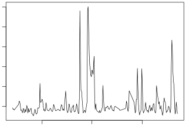

NOTE: figure/graphic rendered as an image from the PDF; its content is not machine-readable text. Caption (if any) follows as the next block.

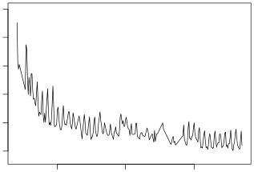

NOTE: figure/graphic rendered as an image from the PDF; its content is not machine-readable text. Caption (if any) follows as the next block.

Apr Jul Oct

1000 2000 3000 4000 5000 6000

Date

Unit sales

(a) New game purchase

Apr Jul Oct

2 4 6 8 10 12

Date

Average usage per game (mins)

(b) Avg. daily game usage

**Notes:** Figure 1a plots the daily unit sales for games on Steam games in the sample of the analysis. 1b plots the daily average usage time for Steam games in the sample of the analysis.

In Figure 1a, we plot the aggregate unit sales for games in our final sample of games on Steam

during the sample period. The two large spikes around mid-summer and late-autumn are due to

two large sales events: the Summer Sale, which occurred between June 23, 2017, and July 5, 2017,

and the Autumn Sale, which occurred between November 22, 2017, and November 28, 2017.

Similarly, in Figure 1b, we plot the average usage time in minutes for our final sample. On

average, users on Steam spent 50.6 minutes per day playing games on Steam. In general, game

usage on Steam has a downward trend. This downward trend reflects the fact that our sample is

a fixed cohort of users and, over time, some of the initially active participants become inactive or

exit. Game usage also shows a clear weekdays/weekend variation.

In Table 2, we present descriptive statistics of gaming-related videos and videos about Steam

games on YouTube. We search for the keywords “sponsor,” “trailer,” “preview” and “review” in

the video description and video title<sup>18</sup>. Only 5.1% of the videos in our sample contain the word

sponsor (which also includes sponsorship by companies in other categories, such as VPN and meal

18We also search for the same words in Chinese, German, Japanese, Portuguese and Spanish as well

13

Electronic copy available at: https://ssrn.com/abstract=3884038

Page 14

delivery services), 1.8% contain the word trailer, and only 2.3% are previews or explicit reviews.

This finding suggests most of our videos are original video posts by content creators and not

sponsored by video games. Some game genres clearly draw more attention from content creators

and viewers than others. Action is the most popular genre, with 71,555 video posts and the average

video receiving 315,836 cumulative views.

We use two measures of engagement for YouTube videos: comments, and likes. The average

video in our samples has over 8,392 likes and 765 comments. In our analysis, we consider these

measures in relation to the total number of views. On average, 4% of viewers like a video, and

0.4% leave a comment.

#### **3.3 Model Free Evidence**

We now use model-free evidence to explore the impact YouTube videos have on the purchase and

usage of video games. In figure 2, we plot average log unit sales and and log usage of Steam games

one day before, the day of, and one day after the release of a YouTube video about a game. The

day that a YouTube video is launched is associated with a 1% reduction in game sales (*p <* 0*.*001),

and a 2.5% increase in game usage (*p <* 0*.*001), when compared to previous day. These trends

continue when we compare the day before and after the release of a YouTube video. After the

release of a video, unit sales are 2.8% lower than the day before the video release (*p <* 0*.*001),

while average usage is 2.5% higher (*p <* 0*.*001).

The fact that posting YouTube videos may, in fact, decrease sales is counter to much of the

current industry wisdom. Most video game developers allow YouTube influencers to freely post

videos about their game, and there are popular services, such as keymailer.co, which facilitate the

distribution of free copies of games to YouTube influencers. If YouTube videos decreased sales,

then this would suggest that those practices are not optimal for developers.

However, this model-free evidence does not account for how and when influencers choose to

create videos, nor does it account for common shocks that may increase both video production and

game purchase and usage. We present our strategy for estimating the effect of YouTube videos

14

Electronic copy available at: https://ssrn.com/abstract=3884038

Page 15

Table 2: Summary Statistics for YouTube Videos

[output not shown]

NOTE: table converted from PDF layout to HTML text; cell boundaries are reconstructed. See PDF if exact alignment matters.

*Action* 71,555 315.84 118.22 754.18 0.01 35,694.42 *Adventure* 42,853 350.40 122.34 1,001.42 0.01 64409.00 *Casual* 3,943 315.66 136.85 622.47 1.23 9,856.10 *Role-playing* 8,193 196.24 81.93 410.87 0.33 10,803.34 *Simulation* 13,759 358.84 135.40 951.53 0.79 46,268.28 *Sports* 5,512 267.35 136.72 450.70 0.58 11,978.85 *Strategy* 7,494 318.84 91.85 1501.18 0.01 64,409.00 **Notes:** This table presents the summary statistics for YouTube gaming channels and videos related to Steam games in our final sample. Channel information on subscribers, cumulative views, and videos posted for the top 3,000 gaming channels are dated March 18, 2018. Summary statistics for YouTube videos are calculated at the video level. The game genre definition is not mutually exclusive so each video can fall into multiple genres.

while accounting for these threats to identification in the next section.

### **4 Empirical Strategy**

In this section, we describe our empirical strategy including the model and identification strategy.

The identification strategy focuses on estimating the effect YouTube videos have on game sales

and usage. The strategy is designed to address endogeneity arising from both simultaneity bias

15

Electronic copy available at: https://ssrn.com/abstract=3884038

Page 16

Figure 2: Game purchase and usage before and after YouTube video posts

Day −1 Day 0 Day 1

Days from a YouTube video

Log units

1.40 1.41 1.42 1.43 1.44 1.45 1.46 1.47

Day −1 Day 0 Day 1

Days from a YouTube video

Log usage (minutes)

2.15 2.20 2.25 2.30 2.35

**Notes:** This figure plots the average log unit sales and usage of the Steam games before, on the day of, and after the day of the posting of a related YouTube video.

and feedback effects. Our solution to this problem leverages a delay in the timing of video uploads

on the YouTube platform due to the “Adpocalypse” event.

#### **4.1 Model**

The baseline model is

*yjt* = *βV <sup>δ</sup>*

**equation / math rendering (image)**

NOTE: contains mathematical notation; text above is the PDF text layer and symbols may be mis-extracted. Image shows the original.

**equation / math rendering (image)**

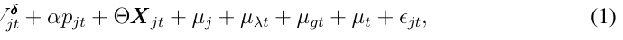

NOTE: contains mathematical notation; text above is the PDF text layer and symbols may be mis-extracted. Image shows the original.

where *pjt* is the price of game *j* on date *t*; *X jt* are other time-varying variables of game *j*

on date *t*, including the game update and store front-page feature dummies; *µj* is the game fixed

effect; *µλ*(*t*) is the *λ*(*t*) weeks since game release fixed effect; *µgt* is the game genres-time fixed

16

Electronic copy available at: https://ssrn.com/abstract=3884038

Page 17

effect<sup>19</sup>; *µt* is the time fixed effect; and *ϵjt* is the unobserved demand shock. *yjt* is the outcome

variable of interest. The outcome variables include both the logarithm of consumer game purchase

and the logarithm of game usage for game *j* on date *t*.

The primary focus is on estimating *β*, the effect that videos have on these outcome variables.

Because consumers can watch these videos after the release date of the video, the effect of videos

could be long-lasting. To capture this potential feature, we model the effect of individual videos

through a ‘video stock’ variable *V <sup>δ</sup>*

*jt*<sup>.</sup> <sup>Let videos</sup>*<sup>jt</sup>* <sup>be the number of YouTube videos from the top</sup>

3,000 channels that were released on date *t* about game *j*. The video stock variable is defined as

*V <sup>δ</sup>*

**equation / math rendering (image)**

NOTE: contains mathematical notation; text above is the PDF text layer and symbols may be mis-extracted. Image shows the original.

*jt* <sup>=</sup><sup>videos</sup>*<sup>jt</sup>* <sup>+</sup>*<sup>δ</sup>*<sup>1</sup>

**equation / math rendering (image)**

NOTE: contains mathematical notation; text above is the PDF text layer and symbols may be mis-extracted. Image shows the original.

7 X

**equation / math rendering (image)**

NOTE: contains mathematical notation; text above is the PDF text layer and symbols may be mis-extracted. Image shows the original.

*τ*=1

**equation / math rendering (image)**

NOTE: contains mathematical notation; text above is the PDF text layer and symbols may be mis-extracted. Image shows the original.

videos*jt−τ* + *δ*2

**equation / math rendering (image)**

NOTE: contains mathematical notation; text above is the PDF text layer and symbols may be mis-extracted. Image shows the original.

14 X

**equation / math rendering (image)**

NOTE: contains mathematical notation; text above is the PDF text layer and symbols may be mis-extracted. Image shows the original.

*τ*=8

**equation / math rendering (image)**

NOTE: contains mathematical notation; text above is the PDF text layer and symbols may be mis-extracted. Image shows the original.

videos*jt−τ,* (2)

**equation / math rendering (image)**

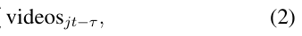

NOTE: contains mathematical notation; text above is the PDF text layer and symbols may be mis-extracted. Image shows the original.

Where *δ*=*{δ*1 ,*δ*2*}* indexes the video stock function, and the parameters *δ*1 and *δ*2 are multipliers

on the effect of a video prior to the current period. These multipliers capture the depreciation (or

appreciation) of the effect of videos that consumers watch day(s) after their release. In our main

specification, the time horizon for the video stocks is two weeks allowing each of the two weeks

to have a separate multiplier<sup>20</sup>.

#### **4.2 Identification Issues**

Our goal is to measure the impact of YouTube videos posted by influencers on both game sales

and game usage. The empirical specification controls for the primary influences on sales and

usage, including game prices, game updates, time since game release, and front-page promotions,

along with a rich set of fixed effects that control for game genre-specific seasonality and game-

specific characteristics. These controls address the most plausible drivers of video game sales and

19As described in section 3.2, the definitions of game genres are not mutually exclusive on Steam. A game’s model, therefore, will include a linear combination of genre-time fixed effects based on the set of genres associated with that game.

20As a robust check, we also test our analysis by considering one and three weeks of lagged videos with each week having its own multiplier. We report the estimation results in table 7 in the Appendix. Our results are qualitatively similar. We also note that we evaluated models with finer disaggregation of the effects and found the qualitative results were unchanged.

17

Electronic copy available at: https://ssrn.com/abstract=3884038

Page 18

usage that content creators could use to anticipate future interest in a particular game. However,

causal inference is complicated by the fact that influencers select the level of the treatment (i.e.,

videos) and may benefit from making videos about games with relatively higher sales and usage.

This feature leads to the fixed effects estimate of 1 being biased due to two violations of strict

exogeneity, i.e., *∀τ, t ∈T, E*(*videojtϵjτ*) = 0.

**equation / math rendering (image)**

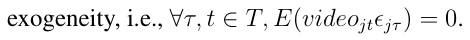

NOTE: contains mathematical notation; text above is the PDF text layer and symbols may be mis-extracted. Image shows the original.

First, the model may be subject to simultaneity bias, which would occur if influencers were

able to observe a positive shock, *ϵjt*, to game purchase or usage that is not captured by our set of

control variables, and time the release of videos to the positive shock. Such timed videos would

induce a contemporaneous positive correlation between YouTube videos and game purchase or

usage that would not be a causal relationship, and therefore *E*(*videosjtϵjt*)*̸* = 0.

Second, influencers might release additional videos in response to *previous* positive shocks

to purchase and usage. Video game sales and usage are strongly autocorrelated for a number of

reasons, including word-of-mouth and advertising campaigns that can last for multiple days. Influ-

encers are incentivized to chase such positive shocks to generate more views of YouTube content

creators’ videos. Such production in response to positive shocks would create a “feedback effect”,

where treatment is positively correlated with prior error terms. This results in *E*(*videojtϵjτ*)*̸* =

0*, τ < t*, which violates the strict exogeneity assumption required for fixed effect estimation.

Our identification strategy addresses the endogeneity concerns related both to the simultaneity

bias and the feedback effect, which stem from the treatment being correlated with both current and

previous error terms. To address these issues, we show that in the specific context of YouTube

videos during 2017, an event known as “Adpocalypse” led content creators to systematically de-

lay the release of their videos. This feature motivates what would normally be an unrealistic

assumption as an exclusion restriction–the release of videos is independent of idiosyncratic shocks

to purchase and usage on the current day. With this exclusion, we directly rule out simultaneity

bias. Because this exclusion also rules out correlation between the lagged treatment and the lagged

shock, it enables us to use the lagged treatment variable as an instrument in a first-difference es-

timation, which does not suffer from bias due to the feedback effect. We discuss the institutional

18

Electronic copy available at: https://ssrn.com/abstract=3884038

Page 19

details of the “Adpocalpyse” and present supporting evidence in the following section, and then

formally construct our estimator in Section 4.4.

#### **4.3 Content Creation on YouTube and the “Adpocalypse”**

YouTube content creators generate advertising revenue based on the number of views of their

videos. Most videos garner the largest number of views in the window just after being posted<sup>21</sup>.

Before 2017, immediately after a content creator posted a video, YouTube showed ads to viewers.

However, posting a video is a time-consuming process. To produce a new video on a YouTube

channel, the producer must record the footage, edit the video, upload the large video file to

YouTube, and wait for YouTube to encode and process the video. Only then is the video made

available for viewing and advertisements. In 2017, each of these steps could take hours, already

limiting posting in response to same-day shocks.

In 2017 YouTube changed its advertising policy in a way that further constrained posting within

a day of a shock. In March of 2017, the Wall Street Journal wrote a series of articles on how ad-

vertisements for the world’s major brands were being played before morally objectionable content

on YouTube. This article caused large advertisers to pull out of the platform en masse (Nicas,

2017*a*,*b*), similar to more recent cases with X, formerly known as Twitter.<sup>22</sup> The 2017 event be-

came known as “Adpocalypse”<sup>23</sup>.

To combat advertisers’ concerns, YouTube started to apply a machine learning algorithm after

the content producer uploaded a video. The algorithm identified videos with *potentially* inappro-

priate content. Videos identified as inappropriate would be demonetized, i.e., barred from having

advertisements. While demonetized, the video was still posted and available for users to watch.

However, because YouTube would not run any advertising, the content creator would not receive

any revenue.

21For example, social media marketing tool SocialPilot reports that “videos tend to get most of their views in the first 2 days”. https://www.socialpilot.co/blog/best-time-to-post-on-youtube

22https://www.nytimes.com/2023/11/24/business/x-elon-musk-advertisers.html 23See Dunphy (2017).

19

Electronic copy available at: https://ssrn.com/abstract=3884038

Page 20

The algorithm was known to be tuned to have many false positives, so that most, if not all,

videos a game channel posted would be demonetized. Large content creators, like those in our

data, could request a manual appeal to argue that their content was appropriate. YouTube then

manually evaluated these cases. This appeal, review and resolution took anywhere from hours to a

couple of days. Because most views of a channel tend to be near the time of posting a new video,

leaving a public video demonetized for even a few hours could cost the game channel a significant

proportion of the revenue from videos.

To prevent this revenue loss, YouTube itself recommended that content creators not immedi-

ately make their videos public. Instead, they recommended first uploading the video privately, and

checking the monetization status after the content had been analyzed by the algorithm. Then, if the

video was mistakenly demonetized, the designation could be appealed, triggering a review of the

video by a human expert. If that appeal was successful, the content creator could post the video

as normal <sup>24</sup>. As we demonstrate empirically below, this added process to ensure monetization led

content creators, already stretched to post within a day, to no longer be able to time videos within

a day of positive shocks.

To evaluate the effect that Adpocalypse had on an influencer’s ability to post a video in a short

time frame, we look at the timing of video posts surrounding one of the most prominent impacts

on a game–game updates. Game updates are observable events that may increase the popularity

of a game by adding new features or content. While we directly control for updates in our main

specification, we believe that investigating video posting around these updates provides evidence

for how influencers would post around other unobserved positive demand shocks, such as growing

word-of-mouth.

If influencers are observed to increase their posting of videos on the day of an update, then they

24YouTube itself recommended the following: “If you want to check the monetization status before making the video public, you can upload it as unlisted or private. If you think we got it wrong and your channel has more than 10,000 subscribers, you can appeal, and we will review your unlisted/private video regardless of the view count. We do this because we want to make sure that videos from channels that could have early traffic to earn money are not caught in a long queue behind videos that get little to no traffic and have nominal earnings.” Source: https://support.google.com/youtube/forum/AAAAiuErobUGhcnZ1x0RM/?hl=en&gpf=%23!topic%2Fyoutube%2FG-hcnZ1x0RM

20

Electronic copy available at: https://ssrn.com/abstract=3884038

Page 21

are likely to be able to produce and monetize a video on the day that other positive demand shocks

arrive. However, if the level of posting remains the same on the day of the update, then they are

less likely to be able to produce and monetize a video on the day that a positive shock is observed.

To check this, we regress the number of YouTube videos on the 10 days window surrounding

the most recent game update both before and after the Adpocalypse, while also controlling for the

number of days from the previous game update if any, weeks since release fixed effects, game fixed

effects, and date fixed effects. The coefficients of the regressions are plotted in figure 3.<sup>25</sup>

Before the Adpocalypse, game updates are associated with a large increase in video posts, with

multiple days around an observed game update having significantly increased video posts. Video

posts on the day of the game update increased by 0*.*043 (*p <* 0*.*001) compared with the number of

videos on 5 days before the observed game update, suggesting that before Adpocalypse YouTube

influencers could quickly produce and upload videos about a game update.

In contrast, after the Adpocalypse, we observe that updates have a much smaller effect on video

posting. Only 0*.*009 additional videos are posted on the day of a game update, and this difference

is statistically insignificant at 95% level (*p* = 0*.*08). Meanwhile, posts are still significantly higher

in the subsequent two days. The number of videos increased by 0*.*0229 (*p <* 0*.*001) on the first

day, and 0*.*0228 (*p <* 0*.*001) on the second day after an observed game update. This suggests that

Adpocalypse delayed video posts that were made in response to increases in the demand of a video

game. We formally specify this assumption in the next section, and discuss potential violations of

this assumption in section 5.2.

#### **4.4 Estimation**

We develop our estimation strategy by first specifying the error term as an AR(3) serially correlated

error

*ϵjt* =

**equation / math rendering (image)**

NOTE: contains mathematical notation; text above is the PDF text layer and symbols may be mis-extracted. Image shows the original.

3 X

**equation / math rendering (image)**

NOTE: contains mathematical notation; text above is the PDF text layer and symbols may be mis-extracted. Image shows the original.

*τ*

**equation / math rendering (image)**

NOTE: contains mathematical notation; text above is the PDF text layer and symbols may be mis-extracted. Image shows the original.

*ρτϵjt−τ* + *νjt,* (3)

**equation / math rendering (image)**

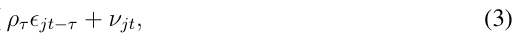

NOTE: contains mathematical notation; text above is the PDF text layer and symbols may be mis-extracted. Image shows the original.

25We also present the full regression results in table 12 in the appendix.

21

Electronic copy available at: https://ssrn.com/abstract=3884038

Page 22

Figure 3: The number of new videos around game updates before and after the adpocalypse

−0.05 0.00 0.05 0.10

Days from the game update

Estimates of No. videos posted

−5 −4 −3 −2 −1 0 1 2 3 4 5

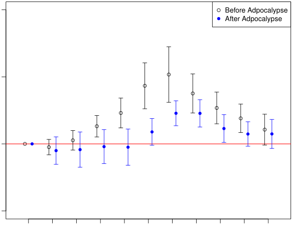

NOTE: figure/graphic rendered as an image from the PDF; its content is not machine-readable text. Caption (if any) follows as the next block.

**text found inside the figure**

Before Adpocalypse After Adpocalypse

**Notes:** This plot shows the regression point estimates and 95% confidence intervals for the number of new videos posted on each date around a game update. We control for game fixed effects, date fixed effects, and weeks since release fixed effects.

where *νjt* is an *i.i.d* unobserved demand shock<sup>26</sup>. From our baseline model in equation (1),

*ϵjt−τ* = *yjt−τ −βV <sup>δ</sup>*

**equation / math rendering (image)**

NOTE: contains mathematical notation; text above is the PDF text layer and symbols may be mis-extracted. Image shows the original.

**equation / math rendering (image)**

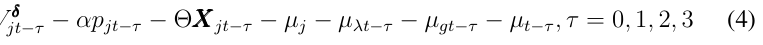

NOTE: contains mathematical notation; text above is the PDF text layer and symbols may be mis-extracted. Image shows the original.

26We allow higher order serial correlation in the unobserved demand shock to ensure that there is no serial correlation in *νjt* due to misspecification. Such a misspecification could be a threat to validity of our identification and results in biased estimates. We choose the three periods empirically by incrementally increasing the serial correlation until the serial correlation estimates ˆ*ρ* decay to near zero.

22

Electronic copy available at: https://ssrn.com/abstract=3884038

Page 23

Combining equations 3 and 4 yields

*yjt* =

**equation / math rendering (image)**

NOTE: contains mathematical notation; text above is the PDF text layer and symbols may be mis-extracted. Image shows the original.

3 X

**equation / math rendering (image)**

NOTE: contains mathematical notation; text above is the PDF text layer and symbols may be mis-extracted. Image shows the original.

*τ*=1

**equation / math rendering (image)**

NOTE: contains mathematical notation; text above is the PDF text layer and symbols may be mis-extracted. Image shows the original.

*ρτyjt−τ* + *β*(*V <sup>δ</sup>*

**equation / math rendering (image)**

NOTE: contains mathematical notation; text above is the PDF text layer and symbols may be mis-extracted. Image shows the original.

*jt <sup>−</sup>*

**equation / math rendering (image)**

NOTE: contains mathematical notation; text above is the PDF text layer and symbols may be mis-extracted. Image shows the original.

3 X

**equation / math rendering (image)**

NOTE: contains mathematical notation; text above is the PDF text layer and symbols may be mis-extracted. Image shows the original.

*τ*=1

**equation / math rendering (image)**

NOTE: contains mathematical notation; text above is the PDF text layer and symbols may be mis-extracted. Image shows the original.

*ρτV <sup>δ</sup>*

**equation / math rendering (image)**

NOTE: contains mathematical notation; text above is the PDF text layer and symbols may be mis-extracted. Image shows the original.

*jt−τ*<sup>) +</sup>*<sup>α</sup>*<sup>(</sup>*<sup>p</sup><sup>jt</sup> <sup>−</sup>*

**equation / math rendering (image)**

NOTE: contains mathematical notation; text above is the PDF text layer and symbols may be mis-extracted. Image shows the original.

3 X

**equation / math rendering (image)**

NOTE: contains mathematical notation; text above is the PDF text layer and symbols may be mis-extracted. Image shows the original.

*τ*=1

**equation / math rendering (image)**

NOTE: contains mathematical notation; text above is the PDF text layer and symbols may be mis-extracted. Image shows the original.

*ρτpjt−τ*)+

**equation / math rendering (image)**

NOTE: contains mathematical notation; text above is the PDF text layer and symbols may be mis-extracted. Image shows the original.

Θ(*X jt −*

**equation / math rendering (image)**

NOTE: contains mathematical notation; text above is the PDF text layer and symbols may be mis-extracted. Image shows the original.

3 X

**equation / math rendering (image)**

NOTE: contains mathematical notation; text above is the PDF text layer and symbols may be mis-extracted. Image shows the original.

*τ*=1

**equation / math rendering (image)**

NOTE: contains mathematical notation; text above is the PDF text layer and symbols may be mis-extracted. Image shows the original.

*ρτX jt−τ*) + ˜*µj* + ˜*µλt* + ˜*µgt* + ˜*µt* + *νjt*

**equation / math rendering (image)**

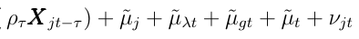

NOTE: contains mathematical notation; text above is the PDF text layer and symbols may be mis-extracted. Image shows the original.

(5)

where ˜*µj* = (1 *−*<sup>P</sup><sup>3</sup>

**equation / math rendering (image)**

NOTE: contains mathematical notation; text above is the PDF text layer and symbols may be mis-extracted. Image shows the original.

**equation / math rendering (image)**

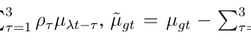

NOTE: contains mathematical notation; text above is the PDF text layer and symbols may be mis-extracted. Image shows the original.

*τ*=1 *<sup>ρ</sup><sup>τ</sup><sup>µ</sup><sup>gt</sup><sup>−</sup><sup>τ</sup>*<sup>,</sup> <sup>and</sup>

**equation / math rendering (image)**

NOTE: contains mathematical notation; text above is the PDF text layer and symbols may be mis-extracted. Image shows the original.

˜*µt* = *µt −*<sup>P</sup><sup>3</sup>

**equation / math rendering (image)**

NOTE: contains mathematical notation; text above is the PDF text layer and symbols may be mis-extracted. Image shows the original.

*τ*=1 *<sup>ρ</sup><sup>τ</sup><sup>µ</sup><sup>t</sup><sup>−</sup><sup>τ</sup>*<sup>.</sup>

**equation / math rendering (image)**

NOTE: contains mathematical notation; text above is the PDF text layer and symbols may be mis-extracted. Image shows the original.

Importantly, the error term now only includes the contemporaneous transient shock *νjt*. As

we have discussed in section 4.3, Adpocalypse and other technical barriers delays videos to fu-

ture days. Based on this event, we assume video posts are contemporaneously exogenous to the

idiosyncratic portion of the error term, that is *videosjt ⊥⊥νjt*, but allow for video posts to be

correlated with the previous error terms, i.e., *videosjt̸ ⊥⊥ϵjt′, ∀t<sup>′</sup> < t*. Because *νjt* is idiosyncratic,

we can further assume sequential exogeneity, *∀t<sup>′</sup> ≤t, videosjt′ ⊥⊥νjt*, which is weaker than the

strict exogeneity assumption typically made in these kinds of models and settings. Since *V <sup>δ</sup>*

*jt* <sup>is</sup>

**equation / math rendering (image)**

NOTE: contains mathematical notation; text above is the PDF text layer and symbols may be mis-extracted. Image shows the original.

the summation of current and lagged video posts, E(*V <sup>δ</sup>*

*jt<sup>ν</sup><sup>jt</sup>*<sup>) = 0</sup><sup>will hold, and is our fundamental</sup>

identification assumption.<sup>27</sup>

We take first differences of equation 5 to remove game fixed effects ˜*µj*

∆*yjt* =

**equation / math rendering (image)**

NOTE: contains mathematical notation; text above is the PDF text layer and symbols may be mis-extracted. Image shows the original.

3 X

**equation / math rendering (image)**

NOTE: contains mathematical notation; text above is the PDF text layer and symbols may be mis-extracted. Image shows the original.

*τ*=1

**equation / math rendering (image)**

NOTE: contains mathematical notation; text above is the PDF text layer and symbols may be mis-extracted. Image shows the original.

*ρτ*∆*yjt−τ* + *β*(∆*V <sup>δ</sup>*

**equation / math rendering (image)**

NOTE: contains mathematical notation; text above is the PDF text layer and symbols may be mis-extracted. Image shows the original.

*jt <sup>−</sup>*

**equation / math rendering (image)**

NOTE: contains mathematical notation; text above is the PDF text layer and symbols may be mis-extracted. Image shows the original.

3 X

**equation / math rendering (image)**

NOTE: contains mathematical notation; text above is the PDF text layer and symbols may be mis-extracted. Image shows the original.

*τ*=1

**equation / math rendering (image)**

NOTE: contains mathematical notation; text above is the PDF text layer and symbols may be mis-extracted. Image shows the original.

*ρτ*∆*V <sup>δ</sup>*

**equation / math rendering (image)**

NOTE: contains mathematical notation; text above is the PDF text layer and symbols may be mis-extracted. Image shows the original.

*jt−τ*<sup>) +</sup>*<sup>α</sup>*<sup>(∆</sup>*<sup>p</sup><sup>jt</sup> <sup>−</sup>*

**equation / math rendering (image)**

NOTE: contains mathematical notation; text above is the PDF text layer and symbols may be mis-extracted. Image shows the original.

3 X

**equation / math rendering (image)**

NOTE: contains mathematical notation; text above is the PDF text layer and symbols may be mis-extracted. Image shows the original.

*τ*=1

**equation / math rendering (image)**

NOTE: contains mathematical notation; text above is the PDF text layer and symbols may be mis-extracted. Image shows the original.

*ρτ*∆*pjt−τ*)+

**equation / math rendering (image)**

NOTE: contains mathematical notation; text above is the PDF text layer and symbols may be mis-extracted. Image shows the original.

Θ(∆**x***jt −*

**equation / math rendering (image)**

NOTE: contains mathematical notation; text above is the PDF text layer and symbols may be mis-extracted. Image shows the original.

3 X

**equation / math rendering (image)**

NOTE: contains mathematical notation; text above is the PDF text layer and symbols may be mis-extracted. Image shows the original.

*τ*=1

**equation / math rendering (image)**

NOTE: contains mathematical notation; text above is the PDF text layer and symbols may be mis-extracted. Image shows the original.

*ρτ*∆**x***jt−τ*) + ∆*νjt.*

**equation / math rendering (image)**

NOTE: contains mathematical notation; text above is the PDF text layer and symbols may be mis-extracted. Image shows the original.

(6)

Taking this difference results in two endogenous variables. First, the first-differenced lagged

outcome variable ∆*yjt−*1 would be correlated with first-differenced transient shock ∆*νjt* by con-

struction, violating exogeneity as E(∆*yjt−*1∆*νjt*)*̸* = 0. Following Anderson and Hsiao (1982), we

use the two-periods lagged outcome variable *yjt−*2 as an instrument for ∆*yjt−*1.

27Formally, our first difference estimation strategy also assumes that *videosjt ⊥⊥νjt*+1. This holds because *νjt*+1 is a future transient shock.

23

Electronic copy available at: https://ssrn.com/abstract=3884038

Page 24

Second, contemporaneous ∆videos*jt*, which is part of ∆*V <sup>δ</sup>*

*jt*<sup>, may be correlated with past</sup>*<sup>ν</sup><sup>jt</sup><sup>−</sup>*<sup>1</sup>

and thus ∆*νjt*. This correlation comes from the fact that videos released in the current period were

produced in previous periods, but were delayed to be posted on time *t* due to the Adpocalypse.

Therefore, videos*jt* is endogenous to the past unobserved demand shock *νjt−*1 and thus ∆*νjt*. We

use lagged videos *videosjt−*1 to instrument first-differenced contemporaneous videos ∆*videosjt*.

*videosjt−*1 is a valid instrument under our previously assumed exclusion restriction which implies

*videosjt−*1 *⊥⊥νjt−*1.

**equation / math rendering (image)**

NOTE: contains mathematical notation; text above is the PDF text layer and symbols may be mis-extracted. Image shows the original.

Rearranging equation 6,

∆*νjt* =∆*yjt −*

**equation / math rendering (image)**

NOTE: contains mathematical notation; text above is the PDF text layer and symbols may be mis-extracted. Image shows the original.

3 X

**equation / math rendering (image)**

NOTE: contains mathematical notation; text above is the PDF text layer and symbols may be mis-extracted. Image shows the original.

*τ*=1

**equation / math rendering (image)**

NOTE: contains mathematical notation; text above is the PDF text layer and symbols may be mis-extracted. Image shows the original.

*ρτ*∆*yjt−τ −β*(∆*V <sup>δ</sup>*

**equation / math rendering (image)**

NOTE: contains mathematical notation; text above is the PDF text layer and symbols may be mis-extracted. Image shows the original.

*jt <sup>−</sup>*

**equation / math rendering (image)**

NOTE: contains mathematical notation; text above is the PDF text layer and symbols may be mis-extracted. Image shows the original.

3 X

**equation / math rendering (image)**

NOTE: contains mathematical notation; text above is the PDF text layer and symbols may be mis-extracted. Image shows the original.

*τ*=1

**equation / math rendering (image)**

NOTE: contains mathematical notation; text above is the PDF text layer and symbols may be mis-extracted. Image shows the original.

*ρτ*∆*V <sup>δ</sup>*

**equation / math rendering (image)**

NOTE: contains mathematical notation; text above is the PDF text layer and symbols may be mis-extracted. Image shows the original.

*jt−τ*<sup>)</sup>*<sup>−</sup><sup>α</sup>*<sup>(∆</sup>*<sup>p</sup><sup>jt</sup> <sup>−</sup>*

**equation / math rendering (image)**

NOTE: contains mathematical notation; text above is the PDF text layer and symbols may be mis-extracted. Image shows the original.

3 X

**equation / math rendering (image)**

NOTE: contains mathematical notation; text above is the PDF text layer and symbols may be mis-extracted. Image shows the original.

*τ*=1

**equation / math rendering (image)**

NOTE: contains mathematical notation; text above is the PDF text layer and symbols may be mis-extracted. Image shows the original.

*ρτ*∆*pjt−τ*)*−*

**equation / math rendering (image)**

NOTE: contains mathematical notation; text above is the PDF text layer and symbols may be mis-extracted. Image shows the original.

Θ(∆*xjt −*

**equation / math rendering (image)**

NOTE: contains mathematical notation; text above is the PDF text layer and symbols may be mis-extracted. Image shows the original.

3 X

**equation / math rendering (image)**

NOTE: contains mathematical notation; text above is the PDF text layer and symbols may be mis-extracted. Image shows the original.

*τ*=1

**equation / math rendering (image)**

NOTE: contains mathematical notation; text above is the PDF text layer and symbols may be mis-extracted. Image shows the original.

*ρτ*∆*xjt−τ*)*,*

**equation / math rendering (image)**

NOTE: contains mathematical notation; text above is the PDF text layer and symbols may be mis-extracted. Image shows the original.

the following moment condition holds

E(*Z*∆*νjt*) = 0*.* (7)

**equation / math rendering (image)**

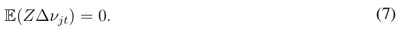

NOTE: contains mathematical notation; text above is the PDF text layer and symbols may be mis-extracted. Image shows the original.

where *Z* are all the exogenous variables. In the exogenous variables *Z*, we include the instrumental

variables of two-periods lagged outcome variable *yjt−*2, and the number of YouTube videos on the

previous day videos*jt−*1. The other variables in *Z* include the first-differenced lagged outcome vari-

ables ∆*yjt−*2 and ∆*yjt−*3; the first-differenced current and past video variables ∆videos*jt−*1*, ...,* videos*jt−*3,

∆<sup>P</sup><sup>7</sup>

**equation / math rendering (image)**

NOTE: contains mathematical notation; text above is the PDF text layer and symbols may be mis-extracted. Image shows the original.

*τ*=1 <sup>videos</sup>*<sup>jt</sup><sup>−</sup><sup>τ</sup><sup>...,</sup>*<sup>∆</sup><sup>P</sup><sup>7</sup>

**equation / math rendering (image)**

NOTE: contains mathematical notation; text above is the PDF text layer and symbols may be mis-extracted. Image shows the original.

*τ*=8 <sup>videos</sup>*<sup>jt</sup><sup>−</sup><sup>τ</sup>*<sup>,</sup>*<sup>...</sup>*<sup>,</sup><sup>∆</sup><sup>P</sup><sup>14</sup>

**equation / math rendering (image)**

NOTE: contains mathematical notation; text above is the PDF text layer and symbols may be mis-extracted. Image shows the original.

*τ*=8 <sup>videos</sup>*<sup>jt</sup><sup>−</sup>*<sup>3</sup>*<sup>−</sup><sup>τ</sup>*<sup>; the</sup>

**equation / math rendering (image)**

NOTE: contains mathematical notation; text above is the PDF text layer and symbols may be mis-extracted. Image shows the original.

first-differenced current and lagged prices, ∆*pjt* to *t−*3; and the first-differenced current and past

control variables ∆*xjt* to *t−*3.

We estimate equation 5 by first accounting for weeks since release fixed effects ˜*µλt*, genre date

fixed effects ˜*µgt*, and date fixed effects ˜*µt* through demeaning. We then estimate equation 6 by

leveraging moment conditions implied by equation 7. We use the generalized method of moments

24

Electronic copy available at: https://ssrn.com/abstract=3884038

Page 25

(GMM) to minimize the following objective function

arg min

*ρ,δ,β,α,*Θ

**equation / math rendering (image)**

NOTE: contains mathematical notation; text above is the PDF text layer and symbols may be mis-extracted. Image shows the original.

(*Z<sup>′</sup>*∆*νjt*(*ρ,δ, β, α,* Θ))*<sup>′</sup>W*(*Z<sup>′</sup>*∆*νjt*(*ρ,δ, β, α,* Θ))*,* (8)

**equation / math rendering (image)**

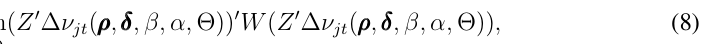

NOTE: contains mathematical notation; text above is the PDF text layer and symbols may be mis-extracted. Image shows the original.

where *Z* are all the exogenous variables and *W* is a positive semi-definite weighting matrix.

We use a two-step approach to get the asymptotically efficient GMM estimates. In the first

step, we set the weighting matrix as *W* = (*Z<sup>′</sup>Z*)*<sup>−</sup>*<sup>1</sup> to get consistent estimates of the parameters

and calculate the corresponding ˆ*νjt*. In the second step, we update the weighting matrix as <sup>ˆ</sup>*W* =

(<sup>P</sup> *Z<sup>′</sup>*

**equation / math rendering (image)**

NOTE: contains mathematical notation; text above is the PDF text layer and symbols may be mis-extracted. Image shows the original.

*jt*<sup>ˆ</sup>*<sup>ν</sup><sup>jt</sup>*<sup>ˆ</sup>*<sup>ν</sup><sup>′</sup>*

**equation / math rendering (image)**

NOTE: contains mathematical notation; text above is the PDF text layer and symbols may be mis-extracted. Image shows the original.

estimates.

In Web appendix section A, we use a Monte Carlo simulation to show that our Adpocalpse-

based estimation strategy obtains consistent estimates of the effect of influencer videos *β* and mul-

tiplier parameters *δ* when influencers on YouTube upload videos based on previous intertemporal

demand shocks.

#### **4.5 Threats to Identification**

There are several potential limitations to our identification strategy. First, our identification strategy

can fail for content sponsored by the game itself. In some cases, video game developers give the

content creator privileged access to new features and content. This allows content creators to pre-

record a video and confirm that it has been approved for monetization before these features launch

on the game. Because of this, we subset our data to organic, non-sponsored videos for our main

results.

Second, our identification assumption is that creators are attempting to maximize advertising

revenue. Content creators who make videos for other reasons, such as Patreon (a platform on which

users can directly support content creators with a monthly subscription) subscribers or intrinsic

utility of publishing videos, may be willing to sacrifice ad revenue to have a timely upload. These

creators may be able to upload a video on the same day that a positive intertemporal demand

25

Electronic copy available at: https://ssrn.com/abstract=3884038

Page 26

shock is realized. While we cannot completely exclude this possibility, we note that during our

sample period, alternative revenue models such as Patreon were less common. <sup>28</sup> We also perform

a robustness check in section 5.2 that removes all videos with direct links to Patreon, and our

findings are qualitative similar.

Third, to reduce the scope of data collection required, we only consider the largest video game

channels. If smaller video game channels have an important effect, and their videos are positively

correlated with videos on larger channels, then our effects will be overestimated.

Fourth, we are only able to study games that both allow their content to be used by content

creators, and that content creators want to produce videos for. It is possible that developers that

choose to limit influencer content would see a more negative spillover than those that allow it.

With these caveats in mind, we now present our empirical findings.

### **5 Empirical Findings**

#### **5.1 Main Results**

In this section, we apply the empirical strategy discussed in the previous section to estimate the

causal effects of YouTube videos. We first show our results for the main effect and then present

estimates of heterogeneous treatment effects.

Table 3 presents our results showing the average effect of influencer-created YouTube videos

on sales and usage. We find that these videos significantly *decrease* game sales but *increase* game

usage. On the day an influencer video is posted, on average, unit sales decrease by 0*.*6%, while

these videos have a long-run effect. In the week after a video releases, the estimated spillover on

purchases is estimated to be smaller in magnitude but still negative. However, the effect on game

28According to https://graphtreon.com/patreon-stats, the monthly payouts for all video content on Patreon was just under 2.5 million at the start of our sample.

26

Electronic copy available at: https://ssrn.com/abstract=3884038

Page 27

Table 3: The impact of YouTube videos on demand of Steam games

|  | l og unitsalesjt | l og usagejt (mins) |
| --- | --- | --- |
|  | (1) | (2) |
| Videosjt β | 0 006∗ − . (0 003) . | 0 006∗∗∗ . (0 002) . |
| Multiplierjt−1 δ to t−7 1 | 0 642∗ . (0 256) . | 1 591∗∗∗ . (0 319) . |
| Multiplierjt−8 δ to t−14 2 | 0 222 − . (0 259) . | 1 196∗∗∗ . (0 298) . |
| Dependent vart−1(ρ1) | 0 269∗∗∗ . (0 012) . | 0 327∗∗∗ . (0 012) . |
| Dependent vart−2(ρ2) | 0 115∗∗∗ . (0 007) . | 0 065∗∗∗ . (0 007) . |
| Dependent vart−3(ρ3) | 0 030∗∗∗ . (0 004) . | 0 024∗∗∗ . (0 005) . |
| Pricejt | 0 025∗∗∗ − . (0 001) . | 0 003∗∗∗ − . (0 001) . |
| Gameupdatejt | 0 001 − . (0 005) . | 0 030∗∗∗ − . (0 005) . |
| Storefeaturepromotionjt | 0 270∗∗∗ . (0 011) . | 0 053∗∗∗ . (0 009) . |
| WeekssincereleaseFE | Yes | Yes |
| GameFE | Yes | Yes |
| Genre-DateFE | Yes | Yes |
| DateFE | Yes | Yes |
| Observations | 135 643 , | 135 643 , |

NOTE: table converted from PDF layout to HTML text; cell boundaries are reconstructed. See PDF if exact alignment matters.

*∗∗∗p <* 0*.*001; *∗∗p <* 0*.*01; *∗p <* 0*.*05; *†p <* 0*.*1

**equation / math rendering (image)**

NOTE: contains mathematical notation; text above is the PDF text layer and symbols may be mis-extracted. Image shows the original.

usage is estimated to be larger in the two weeks following a video post. Based on the estimates

the spillover effect and the multiplier parameters, the long-run elasticities of YouTube influencer

videos on game purchase and game usage are *−*0*.*007 and 0*.*037 respectively.<sup>29</sup>.

Our estimates of the spillover effects of YouTube influencer videos are comparable in magni-

tude to other formats of promotion activities. In terms of product purchase, Shapiro et al. (2021)

29We use the point estimates of ˆ*β* and ˆ*δ* from table 3 and observed number of YouTube videos in our sample to calculate the elasticities and report the average with positive YouTube influencer videos. When calculating the longrun elasticities, we individually increase the observed YouTube influencer videos at each date by 1% and calculate the percentage change of game purchase and usage at the same date and following two-weeks time window.

27

Electronic copy available at: https://ssrn.com/abstract=3884038

Page 28

find that the average elasticity of television advertising is 0*.*023. In terms of product usage, Joo

et al. (2014) report an average elasticity of 0*.*17 of television advertising on product search for

financial services brands, and Huang and Morozov (2023) report an elasticity of 0*.*036 for Twitch

live streaming on Steam game usage over the time span of one week.

As an example, consider *Cuphead*, a popular game in our sample without an in-game purchase

option. Two weeks after release on October 17th, 2017, it sold 47 copies in our sample and was

played for an average of 23.6 minutes by those who owned the game. On that day, 14 videos were

posted, with a total cumulative view count of 18,381,415. Furthermore, in the previous two weeks,

a total of 335 videos were posted, with a total cumulative view count of 126,370,267. Based on our

point estimates and sample, we estimate that, in the absence of these influencer videos, *Cuphead*

would have sold 0.64 more copies. Translating to the population, since our sample started from 1

million users randomly selected from 350 million registered users on Steam (see section 3), a back-

of-the-envelope calculation suggests that YouTube videos on *Cuphead* lead to 0*.*64 *×* 350 = 224

fewer copies sold on that date. *Cuphead* cost 20 USD in the United States, and Steam charged a

30% of all revenues earned. Therefore, we estimate that *Cuphead* had sales of $329,000 on that day

(47*×*350*×*20), and sales would have been $4,480 higher without YouTube videos. Because Steam

takes 30% of revenue from game sales, the developers of *Cuphead* saw their revenue decrease by

$3,136 due to YouTube videos.

The other coefficients in our model also have the expected sign and reasonable magnitudes. Our

estimates of *ρ* imply that the unobservable characteristics are auto-correlated by up to three periods.

We find that prices have a larger effect on sales, and a smaller effect on usage.<sup>30</sup> We estimate that

a discount of 10 dollars increases sales by 25%, and increases usage by 3%. Our findings about

YouTube videos are robust to both using lagged prices as price instruments and when we drop the

price variables from the specification. Similarly, being featured on the store’s front page has the

expected significant positive effect on sales and usage, and the effect on purchases is larger. Game

updates do not appear to have an important impact on sales given the other control variables, but

30In web appendix table 10, we show that our results are similar when we drop price from the model and when we instrument for price with lagged prices.

28

Electronic copy available at: https://ssrn.com/abstract=3884038

Page 29

significantly decrease game usage. This is possibly because a game update means that existing

players will have to download the update before actually playing the game.

As noted in Section 4.2, a fixed effects estimator may be biased in our context due to a feedback

effect, wherein influencers produce videos in response to previous attention to the game, violating

strict exogeneity. In most settings it is very difficult to address this feedback effect concern con-

vincingly. We illustrate with our setting the potential size of this concern. To do so, we re-estimate

our model using a fixed-effect model to see how much this feedback effect would have biased the

estimation results. The results of this analysis are presented in Appendix Table 13. Contrary to our

main findings and the model-free evidence in figure 2, this analysis finds that influencer videos in-

crease, rather than decrease sales of video games. While only one case example, this sharp contrast

highlights the potential importance of accounting for feedback effects in settings where economic

agents can adjust the level of treatment in reaction to previous shocks.<sup>31</sup>

#### **5.2 Robustness Checks**

Our approach has several potential limitations and threats to identification that we address with

robustness checks. First, some influencers may have prior knowledge of future idiosyncratic shocks

*ν*. For example, video game developers may share their release schedules or marketing plans with

large influencer, and, in some cases, the developer may even give advanced access to upcoming

content so that influencers can post videos just as the content launches. Even within the constraints

of the Adpocalypse, this would lead to a simultaneity bias in our estimates.

Building on section 4.3, we looked for evidence of this pattern through video game updates by

splitting figure 3 that presents video posts relative to update timing by the number of subscribers

each channel has. We find that after Adpocalypse, influencers in the 1*,* 000 largest channels do

have significantly more video posts on the day a video game update launches (0*.*006*, p <* 0*.*01),

while the remaining 2,000 influencers do not (0*.*003*, p* = 0*.*46). While this fact alone does not bias

our estimates as updates are controlled for in our analysis, it may indicate that the top channels

31We thank the review team for helping us identify and address this bias.

29

Electronic copy available at: https://ssrn.com/abstract=3884038

Page 30

have knowledge of other unobservables that are not accounted for in our estimation, which would

lead to a positive bias in our estimated effects.

To see if this potential concern affects our findings, we rerun our analysis on the set that we

showed has no significant lift in updates–i.e., excluding the top 1*,* 000 influences from the top

3*,* 000 influencers. Our results are presented in column 2 of Table 4 for game purchase and column

2 of Table 5 for game usage. We find that the results are qualitatively similar to our main findings,

with video posts reducing sales but increasing usage.

Another concern is that video channels might adjust over time to the Adpocalypse policy, mak-

ing them better able to respond to immediately post a video after observing a demand shock. This

these months, even the largest channels may not have fully adapted to the new uploading pro-

cedure, and so would be more likely to delay their video posts. The results of this analysis are

reported in column 3 in Table 4 and 5. Our findings are again qualitative similar to and not statis-

tically distinguishable from our main results, although they are less statistically significant due to

the meaningful reduction in sample size.

Some influencers may not directly value YouTube ad revenue. Instead, they may get com-

pensated in other ways, such as sponsorship or direct donations through Patreon.com, a platform

where users can directly fund content creators. In this case, the influencer may choose to post their

content as quickly as possible to maximize its freshness, even at the risk of forgoing advertising

revenue. We test this possibility in two ways. First, we rerun our analysis while excluding any

videos whose description indicates that it is a sponsored video, game trailer, game preview, and

reviews video. Second, we rerun our analysis removing videos that have direct links to a Patreon

page. The results of this analysis are presented in column 4 and 5 in Table 4 and 5. In both

robustness checks, our results are qualitatively similar to our main findings.

Finally, some influencers may directly upload recordings of live streams from Twitch or YouTube,

wherein they play a game for an audience for hours at a time. The creator may choose to not mon-

30

Electronic copy available at: https://ssrn.com/abstract=3884038

Page 31

etize these streams, and they often would be uploaded quickly. We check for this possibility by

rerunning our analysis on the set of videos least likely to have these potentially problematic cases.

Specifically, we rerun the analysis using only videos that are two hours or shorter in duration. This

robustness check is presented in columns 6 in Table 4 and 5.

Table 4: Robustness checks for identification on game purchase

|  |  | log unit salesjt |  |  |
| --- | --- | --- | --- | --- |
|  | Main | Excl topchannels 1sthalf Excl sponsored . . | Excl patreon . | Onlyshort |
| Videosjt β | 0006∗ − . (0003) . | 0008∗ 0003 0006∗ − . − . − . (0003) (0005) (0003) . . . | 0006∗ − . (0003) . | 0006∗ − . (0003) . |
| Multiplierjt−1 δ to t−7 1 | 0642∗ . (0256) . | 0597∗ 1718 0883∗∗ . . . (0235) (1788) (0336) . . . | 0705∗ . (0290) . | 0640∗ . (0258) . |
| Multiplierjt−8 δ to t−14 2 | 0222 − . (0259) . | 0026 0483 0253 − . − . − . (0214) (1118) (0304) . . . | 0317 − . (0311) . | 0259 − . (0277) . |
| Dependent vart−1(ρ1) | 0269∗∗∗ . (0012) . | 0270∗∗∗ 0221∗∗∗ 0270∗∗∗ . . . (0012) (0017) (0012) . . . | 0269∗∗∗ . (0012) . | 0269∗∗∗ . (0012) . |
| Dependent vart−2(ρ2) | 0115∗∗∗ . (0007) . | 0116∗∗∗ 0100∗∗∗ 0116∗∗∗ . . . (0007) (0010) (0007) . . . | 0115∗∗∗ . (0007) . | 0115∗∗∗ . (0007) . |
| Dependent vart−3(ρ3) | 0030∗∗∗ . (0004) . | 0030∗∗∗ 0028∗∗∗ 0030∗∗∗ . . . (0004) (0006) (0004) . . . | 0030∗∗∗ . (0004) . | 0030∗∗∗ . (0004) . |
| Pricejt | 0025∗∗∗ − . (0001) . | 0025∗∗∗ 0024∗∗∗ 0025∗∗∗ − . − . − . (0001) (0002) (0001) . . . | 0025∗∗∗ − . (0001) . | 0025∗∗∗ − . (0001) . |
| Game updatejt | 0000 − . (0005) . | 0000 0001 0000 − . . − . (0005) (0007) (0005) . . . | 0000 − . (0005) . | 0000 − . (0005) . |
| Store feature promotionjt | 0270∗∗∗ . (0011) . | 0270∗∗∗ 0301∗∗∗ 0270∗∗∗ . . . (0011) (0017) (0011) . . . | 0270∗∗∗ . (0011) . | 0270∗∗∗ . (0011) . |
| WeekssincereleaseFE | Yes | Yes Yes Yes | Yes | Yes |
| GameFE | Yes | Yes Yes Yes | Yes | Yes |
| Genre-Date FE | Yes | Yes Yes Yes | Yes | Yes |
| DateFE | Yes | Yes Yes Yes | Yes | Yes |
| Observations | 135 643 , | 135 643 52 970 135 643 , , , | 135 643 , | 135 643 , |

NOTE: table converted from PDF layout to HTML text; cell boundaries are reconstructed. See PDF if exact alignment matters.

*• ∗∗∗p <* 0*.*001; *∗∗p <* 0*.*01; *∗p <* 0*.*05; *daggerp <* 0*.*1. This table presents the robustness checks on identification strategy from Adpocalypse on game purchase.

In appendix section B, we also report results of several other robustness checks. First, we

show that our findings are robust to choice of the time windows of two weeks by using one week

and three weeks of lagged videos. Second, we test the impact of potential price endogeneity by

instrumenting prices using lagged prices as instruments and removing the price variable, and find

quantitatively similar results to our main findings. Third, we replace the usage measure with the

log average usage of active user who have played the game in the past two week, and find similar

results. Finally, we show that our results are also robust to excluding observed game updates as

31

Electronic copy available at: https://ssrn.com/abstract=3884038

Page 32

Table 5: Robustness checks for identification on game usage

|  |  | log usagejt (mins) |  |  |  |  |
| --- | --- | --- | --- | --- | --- | --- |
|  | Main | Excl topchannels . | 1sthalf | Excl sponsored . | Excl patreon . | Onlyshort |
| Videosjt β | 0006∗∗∗ . (0002) . | 0007∗∗∗ . (0002) . | 0004∗ . (0002) . | 0006∗∗ . (0002) . | 0006∗∗∗ . (0002) . | 0006∗∗∗ . (0002) . |
| Multiplierjt−1 δ to t−7 1 | 1591∗∗∗ . (0319) . | 1540∗∗∗ . (0263) . | 1728∗∗ . (0629) . | 1774∗∗∗ . (0398) . | 1557∗∗∗ . (0299) . | 1580∗∗∗ . (0305) . |
| Multiplierjt−8 δ to t−14 2 | 1196∗∗∗ . (0298) . | 0985∗∗∗ . (0219) . | 1633∗ . (0726) . | 1331∗∗∗ . (0368) . | 1212∗∗∗ . (0293) . | 1190∗∗∗ . (0290) . |
| Dependent vart−1(ρ1) | 0327∗∗∗ . (0012) . | 0327∗∗∗ . (0012) . | 0332∗∗∗ . (0018) . | 0327∗∗∗ . (0012) . | 0327∗∗∗ . (0012) . | 0327∗∗∗ . (0012) . |
| Dependent vart−2(ρ2) | 0065∗∗∗ . (0007) . | 0065∗∗∗ . (0007) . | 0064∗∗∗ . (0010) . | 0064∗∗∗ . (0007) . | 0065∗∗∗ . (0007) . | 0065∗∗∗ . (0007) . |
| Dependent vart−3(ρ3) | 0024∗∗∗ . (0005) . | 0024∗∗∗ . (0005) . | 0022∗∗ . (0007) . | 0024∗∗∗ . (0005) . | 0024∗∗∗ . (0005) . | 0024∗∗∗ . (0005) . |
| Pricejt | 0003∗∗∗ − . (0001) . | 0003∗∗∗ − . (0001) . | 0003∗∗ − . (0001) . | 0003∗∗∗ − . (0001) . | 0003∗∗∗ − . (0001) . | 0003∗∗∗ − . (0001) . |
| Game updatejt | 0030∗∗∗ − . (0005) . | 0030∗∗∗ − . (0005) . | 0002 − . (0009) . | 0030∗∗∗ − . (0005) . | 0030∗∗∗ − . (0005) . | 0030∗∗∗ − . (0005) . |
| Store feature promotionjt | 0053∗∗∗ . (0009) . | 0053∗∗∗ . (0009) . | 0049∗∗∗ . (0014) . | 0053∗∗∗ . (0009) . | 0053∗∗∗ . (0009) . | 0053∗∗∗ . (0009) . |
| WeekssincereleaseFE | Yes | Yes | Yes | Yes | Yes | Yes |
| GameFE | Yes | Yes | Yes | Yes | Yes | Yes |
| Genre-Date FE | Yes | Yes | Yes | Yes | Yes | Yes |
| DateFE | Yes | Yes | Yes | Yes | Yes | Yes |
| Observations | 135 643 , | 135 643 , | 52 970 , | 135 643 , | 135 643 , | 135 643 , |

NOTE: table converted from PDF layout to HTML text; cell boundaries are reconstructed. See PDF if exact alignment matters.

*• ∗∗∗p <* 0*.*001; *∗∗p <* 0*.*01; *∗p <* 0*.*05; *daggerp <* 0*.*1. This table presents the robustness checks on identification strategy from Adpocalypse on game usage.

a control variable. Overall these robustness checks provide a compelling picture that our main

results are unaffected by a wide-range of potential threats to the identification strategy.

#### **5.3 Game and Video Characteristics Heterogeneity**

Next, we evaluate how much the effect of influencer videos on video games depends on the type

of game and features of the YouTube video. We incorporate a number of interaction variables.

Even though we argue and provide evidence that the main effect of video stock is causal under our

research design, these heterogeneous effects are not necessarily causal within that design. Hence,

we offer these results as insights with all the normal caveats for correlational analyses.

In order to investigate such heterogeneous effects, we interact video stock with observable

game and video characteristics. Equation 9 presents the mathematical description of how we cal-

32

Electronic copy available at: https://ssrn.com/abstract=3884038

Page 33

culate these interacted variables, where *qjt* is the characteristic of the game or video,

*V <sup>δ,q</sup>*

**equation / math rendering (image)**

NOTE: contains mathematical notation; text above is the PDF text layer and symbols may be mis-extracted. Image shows the original.

*jt* = videos*jtqjt* + *δ*1

**equation / math rendering (image)**

NOTE: contains mathematical notation; text above is the PDF text layer and symbols may be mis-extracted. Image shows the original.

7 X

**equation / math rendering (image)**

NOTE: contains mathematical notation; text above is the PDF text layer and symbols may be mis-extracted. Image shows the original.

*τ*=1

**equation / math rendering (image)**

NOTE: contains mathematical notation; text above is the PDF text layer and symbols may be mis-extracted. Image shows the original.

videos*jt−τqjt−τ* + *δ*2

**equation / math rendering (image)**

NOTE: contains mathematical notation; text above is the PDF text layer and symbols may be mis-extracted. Image shows the original.

14 X

**equation / math rendering (image)**

NOTE: contains mathematical notation; text above is the PDF text layer and symbols may be mis-extracted. Image shows the original.

*τ*=8

**equation / math rendering (image)**

NOTE: contains mathematical notation; text above is the PDF text layer and symbols may be mis-extracted. Image shows the original.

videos*jt−τqjt−τ,* (9)

**equation / math rendering (image)**

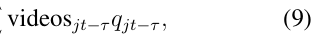

NOTE: contains mathematical notation; text above is the PDF text layer and symbols may be mis-extracted. Image shows the original.

.

Our analysis considers heterogeneity based on the game genres, whether the total sales of the

game are above median, whether the total number of views is above median, and the extent of

engagement the video received, including comments and likes. We report the results of these

analyses in Table 6.<sup>32</sup>

#### **5.3.1 Game characteristics Heterogeneity**

First, we examine whether the spillover effects differ by the genre of game. For example, games

that rely heavily on plot surprises such as role-playing games may have a more negative effect from

videos, since watching a video of the game may be a close substitute for experiencing the story

during play. On the other hand, for other genres, such as strategy or multiplayer eSports games,

which are played competitively, YouTube videos can teach users skills and techniques that help

improve the players’ skill and, as a result, watching such videos may increase the user’s interest in

purchasing and playing the game. We note that we operationalize genres as multiple independent

attributes rather than exclusive categories of a single categorical variable, since each game can

have multiple genres tagged to it.

Consistent with our hypothesis above, we find that that games with the story-tag have more

negative spillovers to purchase than other games. “Indie” games, which are made by small studios,

and “Sports” games also have more negative spillovers to sales. On the other hand, simulation

games and multiplayer games see more positive spillovers to purchase. The effects of genre on

usage are generally weaker. Adventure, Sports, and Story games see significant positive spillovers

to usage , while RPG games see a significant negative spillover (both at the 5% level).

33

Electronic copy available at: https://ssrn.com/abstract=3884038

Page 34

Table 6: Heterogeneous effects from characteristics of games and videos

|  | log unit salesjt | log usagejt (mins) |
| --- | --- | --- |
|  | (1) | (2) |
| Videosjt β | 0043∗∗ . (0014) . | 0012† . (0006) . |
| Multiplierjt−1 to t−7 δ 1 | 1027∗∗∗ . (0097) . | 1602∗∗∗ . (0285) . |
| Multiplierjt−8 to t−14 δ 2 | 0398∗∗∗ . (0087) . | 1954∗∗∗ . (0516) . |
| Videos Stock jt × Action genre | 0012 − . (0009) . | 0003 . (0003) . |
| Videos Stock jt × Adventure genre | 0004 . (0005) . | 0003∗ . (0001) . |
| Videos Stock jt × Casual genre | 0006 . (0014) . | 0004 . (0005) . |
| Videos Stock jt × RPG genre | 0001 . (0006) . | 0005∗ − . (0002) . |
| Videos Stock jt × Simulation genre | 0018† . (0009) . | 0001 . (0003) . |
| Videos Stock jt × Sports genre | 0057∗∗∗ − . (0012) . | 0012∗ . (0005) . |
| Videos Stock jt × Strategy genre | 0023† . (0013) . | 0003 − . (0003) . |
| Videos Stock jt × Multiplayer | 0019∗∗∗ . (0005) . | 0002 − . (0001) . |
| Videos Stock jt × Story | 0032∗ − . (0014) . | 0019∗ . (0007) . |
| Videos Stock jt × Family | 0003 − . (0013) . | 0000 − . (0004) . |
| Videos Stock jt × Platformer | 0001 − . (0008) . | 0006 . (0003) . |
| Videos Stock jt × Indie | 0037∗∗∗ − . (0009) . | 0004 . (0003) . |
| Videos Stock jt × Large game | 0023∗ − . (0010) . | 0014∗ − . (0006) . |
| Videos Stock jt × Cumulative videos exceeded median −0 .012∗∗∗ (0003) . |  | 0002∗ − . (0001) . |
| Videos Stock jt × Like to views ratio | 0214∗∗ − . (0079) . | 0004 − . (0024) . |
| Videos Stock jt × Comment to views ratio | 0813∗ − . (0382) . | 0215∗∗ . (0078) . |
| Dependent vart−1(ρ1) | 0245∗∗∗ . (0011) . | 0302∗∗∗ . (0011) . |
| Dependent vart−2(ρ2) | 0104∗∗∗ . (0006) . | 0053∗∗∗ . (0006) . |
| Dependent vart−3(ρ3) | 0025∗∗∗ . (0004) . | 0018∗∗∗ . (0004) . |
| Pricejt | 0025∗∗∗ − . (0001) . | 0003∗∗∗ − . (0001) . |
| Game updatejt | 0000 − . (0005) . | 0031∗∗∗ − . (0005) . |
| Store feature promotionjt | 0274∗∗∗ . (0011) . | 0050∗∗∗ . (0009) . |
| WeekssincereleaseFE | Yes | Yes |
| GameFE | Yes | Yes |
| Genre-Date FE | Yes | Yes |
| DateFE | Yes | Yes |
| Observations | 135 643 , | 135 643 , |

NOTE: table converted from PDF layout to HTML text; cell boundaries are reconstructed. See PDF if exact alignment matters.

*∗∗∗p <* 0*.*001; *∗∗p <* 0*.*01; *∗p <* 0*.*05; *†p <* 0*.*1

**equation / math rendering (image)**

NOTE: contains mathematical notation; text above is the PDF text layer and symbols may be mis-extracted. Image shows the original.

34

Electronic copy available at: https://ssrn.com/abstract=3884038

Page 35

We next test whether larger or smaller games benefit more from influencer videos. We include

an interaction with whether a game’s total sales are above or below the median value in our sample.

We find that the spillover effects of influencer videos are significantly lower for games with above-

median sales in both game purchase and usage. Smaller, lesser known titles benefit more for

influencer content.

#### **5.3.2 Video Characteristics**

**Engagement** When creating organic content, influencers have little incentive to drive demand

for the games they show. Influencers are primarily concerned with growing their own audience,

as audience size and engagement is the basis for compensation and advertising revenues. They

are advised to directly engage their audience,<sup>33</sup> and many ask their audience to ‘Like, Comment,

and Subscribe’, each of which is an action the user can take to support the creator. The effect

of this self-promotion on influencer spillovers is unclear a priori. For entertainment products, a

more engaged audience may give an influencer more sway over the purchasing habits of their

audience. Alternatively, an influencer who focuses on promoting themselves may be less effective

at promoting the games they exhibit. Similarly, watching influencers who are more engaging could

serve as a better substitute to playing games. If the estimated effect of YouTube videos decreases

with engagement, then influencers desire to engage their audience is misaligned with the incentives

of the video game publisher. To test this possibility, we characterize the engagement of each video

through its Likes-to-views and Comments-to-views ratios, since both Likes and Comments are

measures of engagement.

We find that higher audience engagement is associated with a *smaller* spillover to game pur-

chase, but a *higher* spillover to game usage. Although the coefficient for the comments-to-views

ratio is larger in magnitude, the net effect is smaller because the variation is smaller. If we fix

the value of the parameters of other game and video characteristics at their mean value, based on

the comments-to-views and likes-to-views measures, 68*.*4% of observed videos, if viewed alone,

33See for example https://www.youtube.com/watch?v=zBWGznmxwTg

35

Electronic copy available at: https://ssrn.com/abstract=3884038

Page 36

would act as substitutes for purchases, but less than 0*.*1% act as substitutes for usage. This find-

ing suggests that engagement is an important factor to consider when setting influencer marketing

strategies for acquisition. More engaging videos, and influencers who are more likely to create

such videos, will be less effective and more likely to act as substitutes for purchasing games.

#### **5.3.3 Size and Distribution of Heterogeneity**

In this section, we use the estimated coefficients in Table 6 to calculate the predicted distribution

of elasticities across games. In this calculation, we use the estimated depreciation/appreciation

parameters *δ* to calculate the video stock variables. We fix the characteristics of the videos at its

mean value. And the elasticities of a game is calculated as the average elasticities from all of

its videos. In figures 4a and 4b, we present for purchase and usage, respectively, the estimated

spillovers from YouTube video posts to video games as the elasticities (black circles) along with

the corresponding 95% confidence interval (gray lines). Comparing the two distributions, usage

spillovers are generally positive, while purchase spillovers may be positive or negative. In the

discussion section, we return to the implications of these purchase and usage effects of YouTube

influencer videos.

### **6 Discussion**

In this section, we discuss the implications of our findings. First, we focus on the implications for

firms’ policy on business models. We then present the implications for influencer strategies within

the setting of video games, and finally discuss how our results might relate to legal questions

around intellectual property rights.

#### **6.1 Implications for Business Models**

Our main analysis finds that there is an aggregate negative spillover effect on game sales, but an

aggregate positive effect for game usage. This is consistent with the following story. Consumers

36

Electronic copy available at: https://ssrn.com/abstract=3884038

Page 37

Figure 4: The effects of YouTube videos on purchase and usage of games

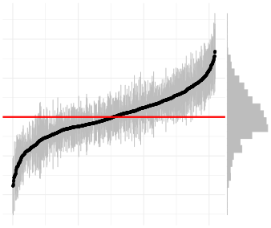

NOTE: figure/graphic rendered as an image from the PDF; its content is not machine-readable text. Caption (if any) follows as the next block.

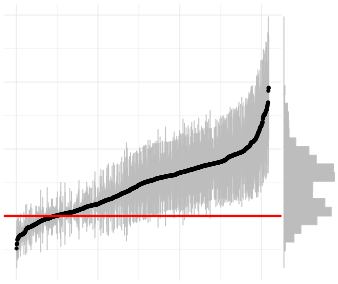

NOTE: figure/graphic rendered as an image from the PDF; its content is not machine-readable text. Caption (if any) follows as the next block.

−0.10

−0.05

0.00

0.05

0.10

0 400 800 1200 Game

Effects of YouTube videos on game purchase

(a) Game purchase

0.000

0.025

0.050

0.075

0 400 800 1200 Game

Elasticities of YouTube videos on game usage

(b) Game usage

**Notes:** Figure 4a and 4b plot the effect size of YouTube videos on game purchase and usage respectively for individual games based on our estimated coefficients for game and video characteristics from 6. Grey lines denote 95% confidence intervals. The histogram of the point estimates are shown on the vertical margin. We also plot the elasticities in figure 8 in appendix.

who are on the margin for buying a video game and searching for new entertainment sources finds

YouTube videos about the product and finds them interesting enough that they substitute away

from purchasing the product. In contrast, for video game owners owners, these videos reignite

or deepen engagement with the video game and complement play. This aggregate result suggests

that video games using an up-front purchase business model should avoid encouraging influencer

content, whereas video games focusing in-game purchases would likely benefit from increasing

influencer content. However, these aggregate results do not tell the full story.

We also find that there is meaningful heterogeneity in the YouTube effects across game and

video characteristics. In Figure 5, we show how firms can adjust their business strategy based on

the specific spillovers they face<sup>34</sup> and calculate the empirical percentage of games that face each

combination of spillover based on the analysis in Table 6.<sup>35</sup>

34Of course, this framework simplifies this problem greatly, ignoring, for example, the margin of collecting revenues from influencers who are profiting from the game versus reducing the number of influencers who are promoting the product.

35The calculation in figure 5 uses point estimates for parsimony. We incorporate statistical uncertainty into our

37

Electronic copy available at: https://ssrn.com/abstract=3884038

Page 38

Figure 5: Example of Policies That Could Be Supported Based On Influencer Spillover Effects.

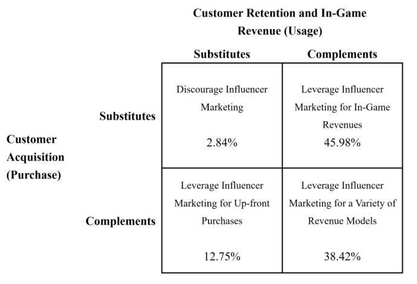

NOTE: figure/graphic rendered as an image from the PDF; its content is not machine-readable text. Caption (if any) follows as the next block.

More than 84% of games are complemented by influencer videos in terms of usage, while only

51% are complements in purchase. This pattern is consistent with our main effect results where

we find positive average effects for usage but negative average effects for purchase.

We find that for 38*.*42% of games, YouTube videos complement both purchase and usage of

games. These firms should encourage influencers to promote their products, potentially by directly

reaching out to influencers or providing free copies of their games. They also have flexibility in

the revenue model they employ, and can emphasize on either up-front purchases or subscription

and in-game revenue from advertising, purchases, and microtransactions.

On other hand, for 2*.*84% of games, YouTube videos substitute both purchase and usage. To

adapt to these purely negative effects, the game publisher might want to discourage influencers

from using their content through a variety techniques. For example, publishers could use copy-

right notices, develop a revenue sharing program for influencers’ advertising such as the Nintendo

results in Web appendix figure 15. While some of our estimated spillovers are insignificant for individual games, in aggregate our results are qualitatively similar in that the majority of games with statistically significant spillovers see videos as substitutes in purchase but complements in usage.

38

Electronic copy available at: https://ssrn.com/abstract=3884038

Page 39

Creators Program, or change their terms of service to limit broadcasting of their games.

The largest set of games, 45.98% of games, face purchase substitutes, but usage complements

(top right quadrant of Figure 5). For these games, publishers cannot rely on up-front purchases

and expect influencer strategies to be effective. Instead, to leverage positive influencer effects, they

need to use revenue models where the usage complements are beneficial. These include subscrip-

tions, in-game advertising, cross-brand promotions,<sup>36</sup> and Downloadable Content (DLC), which

are downloadable add-on modules that are sold separately. Finally, 12*.*75% are substitutes for us-

age but complements for purchase (bottom left quadrant of Figure 5). These firms can emphasize

the up-front revenue they earn when a user buys a game, rather than alternative revenue sources.

#### **6.2 Implications for Influencer Strategies**

In our engagement analyses, we find a strong, consistent pattern. Higher engagement, measured

through likes and comments, is associated with more negative spillover effects for game purchase,

but more positive spillovers for game usage. YouTube influencer videos with high engagement can

serve as substitutes for video game purchase.

This findings suggest that YouTube influencer videos play a different role in game purchase

and game usage. The negative spillover from influencer videos for game purchase suggests that

YouTube videos could become the endpoint of a consumer’s purchase funnel of a video game. A

consumer may be content with watching the YouTube video about a game rather than feeling the

need to buy the game. However, conditional on a consumer has already purchased the game, the

influencer videos play a role as a complement in consumption of the entertainment product, similar

to the relationship between television advertising and product consumption in (Lovett and Staelin,

2016; Tuchman et al., 2018).

This finding also hints that there could be a fundamental tension between the goals of YouTube

video game influencers, who are attempting to grow their channels and generate more advertising

36For example, Pepsi and Call of Duty had a cross brand promotion. https://www.callofduty.com/modernwarfare/pepsi-promotion/official-rules

39

Electronic copy available at: https://ssrn.com/abstract=3884038

Page 40

revenue, and the goals of the video game publishers, whose games the influencers are highlighting.

These misaligned incentives could operate through a number of channels. The most engaging

videos being more entertaining could substitute with video games more readily. The most engaging

videos might focus more on the influencer and less on the game content, leading to lower quality

”free advertising”. The most engaging videos might on average be more negative about the video

game itself than the average video.

Regardless of the reason for the effect, the negative association between engagement and the

effect of video stock on game purchase implies that some current practices might be a concern. In

particular, influencers are often selected on and rewarded for engagement <sup>37</sup>. Our finding suggests

this practice could lead to less effective influencer campaigns. In particular, selecting on and

rewarding based on engagement is risky for firms relying primarily on an up-front purchase revenue

model. On the contrary, firms relying on subscription renewals or an in-game revenue model can

benefit from selecting on and rewarding influencer engagement.

In our setting, paid influencer videos are not a very meaningful proportion of videos. Nonethe-

less, this insight could be relevant both for actions intended to encourage the otherwise organic

posts and could potentially generalize to other settings. For instance, Teixeira et al. (2014) find

that purchase intent has an inverted-U shaped relationship with ad entertainment. If this engage-

ment result is generalizable, it would suggest the need to re-examine practices related to recruiting

and rewarding influencers.

#### **6.3 Intellectual Property Rights**

Our results also provide insight into open legal questions that are important to the rights a firm

has over its intellectual property. Currently, intellectual property holders of video games have the

right to shut down YouTube videos if they file a copyright infringement complaint (Ore, 2017), or

to garner advertising revenue obtained from use of their material. However, there is considerable

37See https://reach-influencers.com/how-do-influencers-get-paid/ and https://nealschaffer.com/how-much-to-payinfluencer/

40

Electronic copy available at: https://ssrn.com/abstract=3884038

Page 41

debate over whether user-generated content, including “Let’s Play” and guides, qualify under the

fair use doctrine (Hagen, 2017; Puddington, 2015), in which case the rights holder would not be

allowed to take these actions.

A key determinant in determining whether content qualifies for fair use is whether demand for

that content enhances demand for the original product<sup>38</sup>. For example, consider the case of *Authors*

*Guild v. Google Inc.*. In ruling in favor of Google, the Court of the Southern District of New York

stated “Google Books enhances the sales of books to the benefit of copyright holders”. <sup>39</sup>

We find that in aggregate, the negative spillovers from influencer-created videos reduce the

demand of copyright holders, and thus may not qualify as fair use. However, even in the cases

where influencer-created videos can harm the purchase of new games, there is evidence that these

videos lead to an increase in usage. Developers who have revenue streams from usage, such as

those with downloadable content, in-game loot boxes, and advertising in their games, may still

benefit as a whole from influencer created videos. Our results elaborate that courts should consider

both purchase and usage spillovers as well as the business model pursued by the firm in question

to evaluate such benefits or harm.

### **7 Conclusion, Limitations, and Future Research**

In this research, we study whether firms can benefit from videos from third-party influencers in the

context of the video game industry. To do so, we collect unique daily panel data of both purchase

and usage of video games. We leverage “Adpocalypse”, a unique feature of our setting, to identify

the effects while accounting for simultaneity bias and feedback effects.

Our empirical results show that influencer-created YouTube videos on average decrease game

sales, but increase usage of the original video game. In addition, we find significant observable

3817 U.S Code §107 regarding fair use: “In determining whether the use made of a work in any particular case is a fair use the factors to be considered shall include...(4) the effect of the use upon the potential market for or value of the copyrighted work.”. Also see Harper & Row v. Nation Enterprises, 471 U.S. 539 (1985): https://supreme.justia.com/cases/federal/us/471/539/.

39https://www.publishersweekly.com/binary-data/ARTICLE ATTACHMENT/file/000/001/1887-2.pdf

41

Electronic copy available at: https://ssrn.com/abstract=3884038

Page 42

purchase and usage. Our findings suggest that video game managers should choose their business

model and manage the intellectual property of their video game products based on the nature of

the product and spillovers they experience.

Our study has several limitations that point to future research directions. First, our study only

identifies the effect of YouTube video posts on video games within a two week window. While we

document a decay in the effect over time, this may not directly generalize to a long-run effect.

Second, because YouTube influencer video posts about video games have features that are

distinct from general commercial use of influencers, future research is needed to determine the

relevance of the measured effects beyond the video game context.

Third, we do not have direct data on the advertising revenue generated by each YouTube video,

nor do we observe viewership at a daily level. With such data, one could help classify which

kinds of user-generated content both expand the market for the original content and attract strong

viewership.

Fourth, our study only looks at the aggregate effect of posting a video. We cannot separately

identify the direct impact of exposure on a single video, as viewing a video may affect the recom-

mendations a user receives. Hence, our estimates assume the process of exposure to video posts is

stable, including recommendation algorithms, search, etc. that, if unstable, could change the effect

sizes.

Fifth, while our main effects are grounded in causal inference, our heterogeneous effects use

observable measures that in some cases are not randomly assigned so that composition effects

could exist across a variable. In particular, this limits the generalizability of our results related to

influencer strategies. Future work can apply a different research paradigm guided by the associa-

tions we obtain between the effect size and these observable variables.

Finally, we believe that the behavior of influencers on YouTube is worthy of further study.

Influencer-created content concerning video games makes up the plurality of content watched on

42

Electronic copy available at: https://ssrn.com/abstract=3884038

Page 43

YouTube, which is the second most visited web site in the world.<sup>40</sup> Taken together, these influ-

encers likely have far-reaching economic and cultural effects.

### **References**

Ameri, Mina, Elisabeth Honka and Ying Xie (2019), ‘Word of mouth, observed adoptions, and

anime-watching decisions: The role of the personal vs. the community network’, *Marketing*

*Science* **38**(4), 567–583.

Anderson, Michael and Jeremy Magruder (2012), ‘Learning From The Crowd: Regression Dis-

countituity Estimates of The Effects of an Online Review Database’, *The Economic Journal*

**122**(563), 957–989.

Anderson, T.W. and Cheng Hsiao (1982), ‘Formulation and estimation of dynamic models using

panel data’, *Journal of Econometrics* **18**(1), 47–82.

**URL:** *https://www.sciencedirect.com/science/article/pii/0304407682900951*

Avery, Jill and Ayelet Israeli (2020), ‘Influencer marketing’, *Harvard Business School Technical*

*Note* **520**.

Bakhshi, Hasan and David Throsby (2014), ‘Digital complements or substitutes? A quasi-field

experiment from the Royal National Theatre’, *Journal of Cultural Economics* **38**(1), 1–8.

Beichert, Maximilian, Andreas Bayerl, Jacob Goldenberg and Andreas Lanz (2023),

‘EXPRESS: Revenue Generation through Influencer Marketing’, *Journal of Marketing*

p. 00222429231217471. Publisher: SAGE Publications Inc.

**URL:** *https://doi.org/10.1177/00222429231217471*

Brackett, Eric (2017), ‘Nintendo rule on live-streams highlights contentious relationship with

40https://www.visualcapitalist.com/the-50-most-visited-websites-in-the-world/

43

Electronic copy available at: https://ssrn.com/abstract=3884038

Page 44

YouTube’.

**URL:** *https://www.digitaltrends.com/gaming/nintendobanslivestreams/*

Chintagunta, Pradeep K., Shyam Gopinath and Sriram Venkataraman (2010), ‘The Effects of On-

line User Reviews on Movie Box Office Performance: Accounting for Sequential Rollout and

Aggregation Across Local Markets’, *Marketing Science* **29**(5), 944–957.

Dewey, Caitlin (2015), ‘Who is PewDiePie, the first person to ever hit 10 billion YouTube views?’.

**URL:** *https://www.washingtonpost.com/news/the-intersect/wp/2015/09/09/who-is-pewdiepie-*

*the-first-person-to-ever-hit-10-billion-youtube-views/?noredirect=on*

Dunphy, Rachel (2017), ‘Can YouTube Survive the Adpocalypse?’.

**URL:** *http://nymag.com/selectall/2017/12/can-youtube-survive-the-adpocalypse.html*

Edwards, Cliff (2013), ‘Valve Lines Up Console Partners in Challenge to Microsoft, Sony’.

**URL:** *https://www.bloomberg.com/news/articles/2013-11-04/valve-lines-up-console-partners-*

*in-challenge-to-microsoft-sony*

Gentzkow, Matthew (2007), ‘Valuing new goods in a model with complementarity: Online news-

papers’, *The American Economic Review* **97**(3), 713–744.

Godes, David and Dina Mayzlin (2004), ‘Using Online Conversations to Study Word-of-Mouth

Communication’, *Marketing Science* **23**(4), 545–560.

Gong, Shiyang, Juanjuan Zhang, Ping Zhao and Xuping Jiang (2017), ‘Tweeting as a Marketing

Tool: A Field Experiment in the TV Industry’, *Journal of Marketing Research* **54**(6), 833–850.

Gu, Xian, Xiaoxi Zhang and P. K. Kannan (2023), ‘EXPRESS: Influencer Mix Strategies in

Livestream Commerce: Impact on Product Sales’, *Journal of Marketing* .

Hagen, Dan (2017), ‘Fair Use, Fair Play: Video Game Performances and Let’s Plays as Transfor-

mative Use’, *Washington Journal of Law, Technology & Arts* **13**(3), 245.

44

Electronic copy available at: https://ssrn.com/abstract=3884038

Page 45

Handrahan, Matthew (2013), ‘Nintendo targets user YouTube videos’.

**URL:** *https://www.gamesindustry.biz/articles/2013-05-16-nintendo-targets-user-youtube-*

*videos*

Haviv, Avery, Yufeng Huang and Nan Li (2020), ‘Intertemporal demand spillover effects on video

game platforms’, *Management Science* **66**(10), 4788–4807.

Hendricks, Ken and Alan Sorensen (2009), ‘Information and the Skewness of Music Sales’, *Jour-*

*nal of Political Economy* **117**(2), 324–369.

Huang, Yufeng and Ilya Morozov (2023), ‘The promotional effects of live streams by twitch influ-

encers’, *Working paper* .

Hwang, Serim, Xiao Liu and Kannan Srinivasan (2022), ‘Voice analytics of online influencers’,

*Working paper* .

Joo, Mingyu, Kenneth C. Wilbur, Bo Cowgill and Yi Zhu (2014), ‘Television Advertising and

Online Search’, *Management Science* **60**(1), 56–73.

Leung, Fine F., Flora F. Gu, Yiwei Li, Jonathan Z. Zhang and Robert W. Palmatier (2022), ‘Influ-

encer marketing effectiveness’, *Journal of Marketing* **86**(6), 93–115.

Lou, Chen and Shupei Yuan (2019), ‘Influencer Marketing: How Message Value and Credibility

Affect Consumer Trust of Branded Content on Social Media’, *Journal of Interactive Advertising*

**19**(1), 58–73.

Lovett, Mitchell J. and Richard Staelin (2016), ‘The Role of Paid, Earned, and Owned Media in

Building Entertainment Brands: Reminding, Informing, and Enhancing Enjoyment’, *Marketing*

*Science* **35**(1), 142–157.

Marshall, Carla (2014), ‘15% of All YouTube Videos Relate to Gaming: Minecraft & Pewdiepie

FTW’.

**URL:** *http://tubularinsights.com/15-per-cent-youtube-gaming-videos/*

45

Electronic copy available at: https://ssrn.com/abstract=3884038

Page 46

Nicas, Jack (2017*a*), ‘AT&T, Verizon Pull Ads From Google Over ‘Hate’ Videos’.

**URL:** *https://www.wsj.com/articles/at-t-pulling-ads-from-google-over-hate-videos-*

*1490206824*

Nicas, Jack (2017*b*), ‘Google’s YouTube Has Continued Showing Brands’ Ads With Racist and

Other Objectionable Videos’.

**URL:** *https://www.wsj.com/articles/googles-youtube-has-continued-showing-brands-ads-with-*

*racist-and-other-objectionable-videos-1490380551*

Ore, Jonathan (2017), ‘Is playing video games on YouTube a copyright infringement? No one

wants to find out - YouTubers playing video games online usually seen as free advertising for

publishers’.

**URL:** *http://www.cbc.ca/news/entertainment/youtube-gaming-pewdiepie-fair-use-1.4309312*

Puddington, James (2015), ‘Fair Play: Economic Justification for Applying Fair Use to the On-

line Streaming of Video Games’, *Boston University Journal of Science and Technology Law*

**21**(2), 413.

Rajaram, Prashant and Puneet Manchanda (2020), ‘Video Influencers: Unboxing the Mystique’,

*Working paper* .

Reimers, Imke and Joel Waldfogel (2020), ‘Digitization and Pre-Purchase Information: The Causal

and Welfare Impacts of Reviews and Crowd Ratings’, *National Bureau of Economic Research* .

Resnikoff, Paul (2016), ‘Music Is Just 4.3% of YouTube Traffic, Research Shows’.

**URL:** *https://www.digitalmusicnews.com/2016/08/16/music-5-percent-youtube/*

Schouten, Alexander P., Loes Janssen and Maegan Verspaget (2020), ‘Celebrity vs. Influencer

endorsements in advertising: the role of identification, credibility, and Product-Endorser fit’,

*International Journal of Advertising* **39**(2), 258–281.

**URL:** *https://doi.org/10.1080/02650487.2019.1634898*

46

Electronic copy available at: https://ssrn.com/abstract=3884038

Page 47

Seiler, Stephan, Song Yao and Wenbo Wang (2017), ‘Does Online Word of Mouth Increase De-

mand? (And How?) Evidence from a Natural Experiment’, *Marketing Science* **36**(6), 838–861.

Shapiro, Bradley T., G¨unter J. Hitsch and Anna E. Tuchman (2021), ‘TV Advertising Effectiveness

and Profitability: Generalizable Results From 288 Brands’, *Econometrica* **89**(4), 1855–1879.

**URL:** *https://www.econometricsociety.org/doi/10.3982/ECTA17674*

Simon, Daniel H. and Vrinda Kadiyali (2007), ‘The effect of a magazine’s free digital content on

its print circulation: Cannibalization or complementarity?’, *Information Economics and Policy*

**19**(3-4), 344–361.

Sonnier, Garrett P., Leigh McAlister and Oliver J. Rutz (2011), ‘A Dynamic Model of the Effect

of Online Communications on Firm Sales’, *Marketing Science* **30**(4), 702–716.

Soper, Taylor (2017), ‘Valve reveals Steam’s monthly active user count and game sales by region’.

**URL:** *https://www.geekwire.com/2017/valve-reveals-steams-monthly-active-user-count-game-*

*sales-region/*

Taylor, Haydn (2019), ‘Minecraft is most popular game on YouTube in 2019 with 100bn views’.

**URL:** *https://www.gamesindustry.biz/articles/2019-12-06-minecraft-is-most-popular-game-on-*

*youtube-in-2019-with-100bn-views*

Teixeira, Thales, Rosalind Picard and Rana El Kaliouby (2014), ‘Why, when, and how much to

entertain consumers in advertisements? a web-based facial tracking field study’, *Marketing*

*Science* **33**(6), 809–827.

Tirunillai, Seshadri and Gerard J. Tellis (2012), ‘Does Chatter Really Matter? Dynamics of User-

Generated Content and Stock Performance’, *Marketing Science* **31**(2), 198–215.

Tuchman, Anna E., Harikesh S. Nair and Pedro M. Gardete (2018), ‘Television ad-skipping, con-

sumption complementarities and the consumer demand for advertising’, *Quantitative Marketing*

47

Electronic copy available at: https://ssrn.com/abstract=3884038

Page 48

*and Economics* **16**(2), 111–174.

**URL:** *http://link.springer.com/10.1007/s11129-017-9192-y*

Valsesia, Francesca, Davide Proserpio and Joseph C Nunes (2020), ‘The positive effect of not

following others on social media’, *Journal of Marketing Research* **57**(6), 1152–1168.

Webb, Kevin (2019), ‘YouTube’s list of the 10 most-watched video games of 2019 proves that

new games aren’t the most popular online’.

**URL:** *https://www.businessinsider.com/youtube-most-watched-video-games-2019-ranked-*

*2019-12*

Webster, Andrew (2015), ‘Nintendo is finally sharing ad revenue with YouTube users’.

**URL:** *https://www.theverge.com/2015/1/29/7938333/nintendo-youtube-affiliate-program*

Wooldridge, Jefrey M. (2010), *Econometric Analysis of Cross Section and Panel Data*, The MIT

Press.

Yang, Jeremy, Juanjuan Zhang and Yuhan Zhang (2021), ‘First Law of Motion: Influencer Video

Advertising on TikTok’, *Working paper* .

Zhang, Weiqing, Zekun Liu, Xiao Liu and Eitan Muller (2023), ‘Doubling Revenues by Adopting

Livestream Shopping: A Synthetic DiD Approach’, *SSRN Electronic Journal* .

**URL:** *https://www.ssrn.com/abstract=4318978*

Zhu, Feng and Xiaoquan (Michael) Zhang (2010), ‘Impact of Online Consumer Reviews on

Sales : The Moderating Role of Product and Consumer Characteristics’, *Journal of Marketing*

**74**(2), 133–148.

48

Electronic copy available at: https://ssrn.com/abstract=3884038

Page 49

### **Appendix A Monte Carlo Simulation**

In order to show our estimation strategy can recover key parameters of our model when Adpoca-

lypse delay YouTube videos to future dates, we perform a set of Monte Carlo simulations. We

assume the outcome variables (purchase and usage) *yjt* follows the following model,

*yjt* = *βV <sup>δ</sup>*

**equation / math rendering (image)**

NOTE: contains mathematical notation; text above is the PDF text layer and symbols may be mis-extracted. Image shows the original.

*jt* <sup>+</sup>*<sup>µ</sup><sup>j</sup>* <sup>+</sup>*<sup>µ</sup><sup>t</sup>* <sup>+</sup>*<sup>ϵ</sup><sup>jt</sup><sup>.</sup>* (10)

**equation / math rendering (image)**

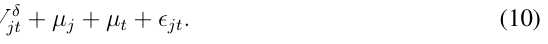

NOTE: contains mathematical notation; text above is the PDF text layer and symbols may be mis-extracted. Image shows the original.

where *V <sup>δ</sup>*

*jt* <sup>is</sup> <sup>the</sup> <sup>video</sup> <sup>stock,</sup> *<sup>µ</sup><sup>j</sup>* <sup>are</sup> <sup>game</sup> <sup>fixed</sup> <sup>effects,</sup> *<sup>µ</sup><sup>t</sup>* <sup>are</sup> <sup>time</sup> <sup>fixed</sup> <sup>effects,</sup> <sup>and</sup> *<sup>ϵ</sup><sup>jt</sup>* <sup>is</sup> <sup>a</sup>

serially correlated error term *ϵjt* that follows an AR(2) process,

*ϵjt* =

**equation / math rendering (image)**

NOTE: contains mathematical notation; text above is the PDF text layer and symbols may be mis-extracted. Image shows the original.

2 X

**equation / math rendering (image)**

NOTE: contains mathematical notation; text above is the PDF text layer and symbols may be mis-extracted. Image shows the original.

*τ*

**equation / math rendering (image)**

NOTE: contains mathematical notation; text above is the PDF text layer and symbols may be mis-extracted. Image shows the original.

*ρτϵjt−τ* + *νjt.*

**equation / math rendering (image)**

NOTE: contains mathematical notation; text above is the PDF text layer and symbols may be mis-extracted. Image shows the original.

The video stock variable *V <sup>δ</sup>*

*jt* <sup>in this simulation includes the contemporaneous videos and also</sup>

videos in the past week. The effect of videos in the past week is multiplied by parameter *δ*.

*V <sup>δ</sup>*

**equation / math rendering (image)**

NOTE: contains mathematical notation; text above is the PDF text layer and symbols may be mis-extracted. Image shows the original.

*jt* <sup>=</sup><sup>videos</sup>*<sup>jt</sup>* <sup>+</sup>*<sup>δ</sup>*

**equation / math rendering (image)**

NOTE: contains mathematical notation; text above is the PDF text layer and symbols may be mis-extracted. Image shows the original.

7 X

**equation / math rendering (image)**

NOTE: contains mathematical notation; text above is the PDF text layer and symbols may be mis-extracted. Image shows the original.

*τ*=1

**equation / math rendering (image)**

NOTE: contains mathematical notation; text above is the PDF text layer and symbols may be mis-extracted. Image shows the original.

videos*jt−τ.*

**equation / math rendering (image)**

NOTE: contains mathematical notation; text above is the PDF text layer and symbols may be mis-extracted. Image shows the original.

Content creators can target demand shocks to produce videos. We specify that videos in ab-

sence of adpocalypse, videos*jt*, would be generated from the following process,

v*jt* = rand v*jt* + *µj* + *µt* + *ϵjt,*

**equation / math rendering (image)**

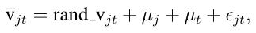

NOTE: contains mathematical notation; text above is the PDF text layer and symbols may be mis-extracted. Image shows the original.

where rand videos*jt* are exogenous videos, and *µj*, *µt*, and *ϵjt* are set to the same values as in

equation 10. This means that a direct estimation of Equation 10 would result endogeneity due to

simultaneity bias, as the error term *ϵjt* appears in both the dependent and independent variables.

Consistent with the evidence in Section 4, we assume that videos produced after “Adpoca-

lypse” v*jt*, are delayed to future days other than the date of the shock by up to a week with equal

probability at each day, resulting in the observed number of videos, videos*jt*.

49

Electronic copy available at: https://ssrn.com/abstract=3884038

Page 50

Figure 6: Model Simulation Estimates

50 100 150 200

−5 0 5

ρ<sup>^</sup>

**equation / math rendering (image)**

NOTE: contains mathematical notation; text above is the PDF text layer and symbols may be mis-extracted. Image shows the original.

1

T

Bias %

50 100 150 200

−5 0 5

ρ<sup>^</sup>

**equation / math rendering (image)**

NOTE: contains mathematical notation; text above is the PDF text layer and symbols may be mis-extracted. Image shows the original.

2

T

Bias %

50 100 150 200

−5 0 5

β<sup>^</sup>

**equation / math rendering (image)**

NOTE: contains mathematical notation; text above is the PDF text layer and symbols may be mis-extracted. Image shows the original.

T

Bias %

50 100 150 200

−5 0 5

δ<sup>^</sup>

**equation / math rendering (image)**

NOTE: contains mathematical notation; text above is the PDF text layer and symbols may be mis-extracted. Image shows the original.

T

Bias %

**Notes:** Each dot represents the average percentage of bias of the estimated parameter at given periods *T*. Error bars shows 95% confidence interval of bias of the simulation estimates from 100 simulations at each value of periods *T*.

We set the value of the four parameters to be estimated as *ρ*1 = 0*.*5, *ρ*2 = 0*.*05, *β* = 0*.*5,

*δ* = 0*.*7. We randomly generate sales of *N* = 500 games for *T* = 50, 100, 150, and 200 periods

respectively along with videos. We perform simulations at each *T* for 100 times.

When *T* = 150, the average percentage of bias<sup>41</sup> for the four parameters are *−*0*.*14%, *−*0*.*72%,

0*.*07%, and 0*.*05% respectively. Using our 100 simulations to build confidence intervals, we cannot

reject that the bias is 0 for each of these 4 parameters. In figure 6, we illustrate the percentage of

bias of the AR(2) serial correlation parameter *ρ*1 and *ρ*2, the impact of videos *β*, the video stock

multiplier parameter *δ* using our estimation procedure. In figure 7, we also plot the distribution of

estimates of parameters with *T* = 150, which is close to the average length of the panel we observe

in our data. All simulations are centered around zero, indicating there is little bias in the estimates.

The simulation results show that when YouTube video uploads are delayed by at least one day, we

can get a consistent estimate of both *ρ* and *β*, even if the videos were produced to target a serially

unobserved demand shock.

41That is, calculate ( *EstimatedP arameter T rueP arameter −*1) *∗*100%.

**equation / math rendering (image)**

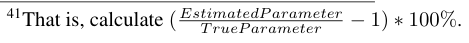

NOTE: contains mathematical notation; text above is the PDF text layer and symbols may be mis-extracted. Image shows the original.

50

Electronic copy available at: https://ssrn.com/abstract=3884038

Page 51

Figure 7: Distribution of Model Simulation Estimates

ρ<sup>^</sup>

**equation / math rendering (image)**

NOTE: contains mathematical notation; text above is the PDF text layer and symbols may be mis-extracted. Image shows the original.

1

Frequency

0.48 0.50 0.52

0 5 10 15 20

ρ<sup>^</sup>

**equation / math rendering (image)**

NOTE: contains mathematical notation; text above is the PDF text layer and symbols may be mis-extracted. Image shows the original.

2

Frequency

0.035 0.045 0.055 0.065

0 10 20 30 40

β<sup>^</sup>

**equation / math rendering (image)**

NOTE: contains mathematical notation; text above is the PDF text layer and symbols may be mis-extracted. Image shows the original.

Frequency

0.492 0.496 0.500 0.504

0 10 20 30

δ<sup>^</sup>

**equation / math rendering (image)**

NOTE: contains mathematical notation; text above is the PDF text layer and symbols may be mis-extracted. Image shows the original.

Frequency

0.695 0.705

0 5 10 15 20

**Notes:** Distribution of simulation estimates at *T* = 150.

### **Appendix B Robustness checks**

51

Electronic copy available at: https://ssrn.com/abstract=3884038

Page 52

Table 7: Robustness checks using different time horizons

|  | l og unitsalesjt |  | l og usagejt (mins) |  |
| --- | --- | --- | --- | --- |
|  | (1) | (2) | (3) | (4) |
| Videosjt β | 0 004† − . (0 003) . | 0 007∗ − . (0 003) . | 0 008∗∗∗ . (0 002) . | 0 006∗∗∗ . (0 002) . |
| Decayjt−1 δ to t−7 1 | 0 662† . (0 339) . | 0 529∗ . (0 235) . | 1 045∗∗∗ . (0 183) . | 1 527∗∗∗ . (0 272) . |
| Decayjt−8 δ to t−14 2 |  | 0 453 − . (0 339) . |  | 1 337∗∗∗ . (0 299) . |
| Decayjt−15 δ to t−21 3 |  | 0 608† − . (0 332) . |  | 0 694∗∗ . (0 211) . |
| Dependent vart−1(ρ1) | 0 272∗∗∗ . (0 012) . | 0 271∗∗∗ . (0 012) . | 0 324∗∗∗ . (0 012) . | 0 327∗∗∗ . (0 012) . |
| Dependent vart−2(ρ2) | 0 116∗∗∗ . (0 007) . | 0 117∗∗∗ . (0 007) . | 0 062∗∗∗ . (0 007) . | 0 063∗∗∗ . (0 007) . |
| Dependent vart−3(ρ3) | 0 030∗∗∗ . (0 004) . | 0 030∗∗∗ . (0 004) . | 0 021∗∗∗ . (0 005) . | 0 028∗∗∗ . (0 005) . |
| Pricejt | 0 025∗∗∗ − . (0 001) . | 0 025∗∗∗ − . (0 001) . | 0 003∗∗∗ − . (0 001) . | 0 003∗∗∗ − . (0 001) . |
| Gameupdatejt | 0 001 − . (0 005) . | 0 003 . (0 005) . | 0 022∗∗∗ − . (0 006) . | 0 029∗∗∗ − . (0 005) . |
| Storefeaturepromotionjt | 0 270∗∗∗ . (0 010) . | 0 271∗∗∗ . (0 011) . | 0 058∗∗∗ . (0 009) . | 0 048∗∗∗ . (0 009) . |
| WeekssincereleaseFE | Yes | Yes | Yes | Yes |
| GameFE | Yes | Yes | Yes | Yes |
| Genre-DateFE | Yes | Yes | Yes | Yes |
| DateFE | Yes | Yes | Yes | Yes |
| Observations | 138 744 , | 132 505 , | 138 744 , | 132 505 , |

NOTE: table converted from PDF layout to HTML text; cell boundaries are reconstructed. See PDF if exact alignment matters.

*∗∗∗p <* 0*.*001; *∗∗p <* 0*.*01; *∗p <* 0*.*05; *†p <* 0*.*1

**equation / math rendering (image)**

NOTE: contains mathematical notation; text above is the PDF text layer and symbols may be mis-extracted. Image shows the original.

52

Electronic copy available at: https://ssrn.com/abstract=3884038

Page 53

Table 8: The impact of YouTube videos on usage of active users

|  | l og usageofactiveusersjt (mins) |
| --- | --- |
|  | (1) |
| Videosjt β | 0 005∗ . (0 003) . |
| Multiplierjt−1 δ to t−7 1 | 1 451∗∗ . (0 549) . |
| Multiplierjt−8 δ to t−14 2 | 0 977∗ . (0 446) . |
| Dependent varjt−1(ρ1) | 0 281∗∗∗ . (0 011) . |
| Dependent varjt−2(ρ2) | 0 061∗∗∗ . (0 006) . |
| Dependent varjt−3(ρ3) | 0 020∗∗∗ . (0 004) . |
| Pricejt | 0 000 . (0 001) . |
| Gameupdatejt | 0 038∗∗∗ − . (0 008) . |
| Storefeaturepromotionjt | 0 023 . (0 014) . |
| WeekssincereleaseFE | Yes |
| GameFE | Yes |
| Genre-DateFE | Yes |
| DateFE | Yes |
| Observations | 135 643 , |

NOTE: table converted from PDF layout to HTML text; cell boundaries are reconstructed. See PDF if exact alignment matters.

*∗∗∗p <* 0*.*001; *∗∗p <* 0*.*01; *∗p <* 0*.*05. Active users are defined as users who have played the game in the past two weeks.

53

Electronic copy available at: https://ssrn.com/abstract=3884038

Page 54

Table 9: Robustness check excluding observed game updates

|  | l og unitsalesjt | l og usagejt (mins) |
| --- | --- | --- |
|  | (1) | (2) |
| Videosjt β | 0 006∗ − . (0 003) . | 0 006∗∗∗ . (0 002) . |
| Decayjt−1 δ to t−7 1 | 0 639∗ . (0 255) . | 1 570∗∗∗ . (0 300) . |
| Decayjt−8 δ to t−14 2 | 0 222 − . (0 259) . | 1 190∗∗∗ . (0 283) . |
| Dependent vart−1(ρ1) | 0 270∗∗∗ . (0 012) . | 0 333∗∗∗ . (0 012) . |
| Dependent vart−2(ρ2) | 0 116∗∗∗ . (0 007) . | 0 067∗∗∗ . (0 007) . |
| Dependent vart−3(ρ3) | 0 030∗∗∗ . (0 004) . | 0 026∗∗∗ . (0 005) . |
| Pricejt | 0 025∗∗∗ − . (0 001) . | 0 003∗∗∗ − . (0 001) . |
| Storefeaturepromotionjt | 0 270∗∗∗ . (0 011) . | 0 056∗∗∗ . (0 009) . |
| WeekssincereleaseFE | Yes | Yes |
| GameFE | Yes | Yes |
| Genre-DateFE | Yes | Yes |
| DateFE | Yes | Yes |
| Observations | 135 643 , | 135 643 , |

NOTE: table converted from PDF layout to HTML text; cell boundaries are reconstructed. See PDF if exact alignment matters.

*∗∗∗p <* 0*.*001; *∗∗p <* 0*.*01; *∗p <* 0*.*05; *†p <* 0*.*1

**equation / math rendering (image)**

NOTE: contains mathematical notation; text above is the PDF text layer and symbols may be mis-extracted. Image shows the original.

54

Electronic copy available at: https://ssrn.com/abstract=3884038

Page 55

Table 10: Robustness checks for price endogeneity

|  | l og unitsalesjt | l og usagejt (mins) |  |
| --- | --- | --- | --- |
|  | Inst price Noprice . | Inst price . | Noprice |
| Videosjt β | 0 006∗ 0 005† − . − . (0 003) (0 003) . . | 0 006∗∗∗ . (0 002) . | 0 005∗∗∗ . (0 002) . |
| Decayjt−1 δ to t−7 1 | 0 618∗ 0 598† . . (0 257) (0 311) . . | 1 591∗∗∗ . (0 318) . | 1 494∗∗∗ . (0 317) . |
| Decayjt−8 δ to t−14 2 | 0 236 0 555 − . − . (0 267) (0 438) . . | 1 156∗∗∗ . (0 287) . | 1 218∗∗∗ . (0 321) . |
| Dependent vart−1(ρ1) | 0 272∗∗∗ 0 326∗∗∗ . . (0 012) (0 011) . . | 0 327∗∗∗ . (0 012) . | 0 328∗∗∗ . (0 011) . |
| Dependent vart−2(ρ2) | 0 116∗∗∗ 0 131∗∗∗ . . (0 007) (0 006) . . | 0 064∗∗∗ . (0 007) . | 0 062∗∗∗ . (0 006) . |
| Dependent vart−3(ρ3) | 0 029∗∗∗ 0 033∗∗∗ . . (0 004) (0 004) . . | 0 024∗∗∗ . (0 005) . | 0 023∗∗∗ . (0 004) . |
| Pricejt | 0 023∗∗∗ − . (0 002) . | 0 001 . (0 001) . |  |
| Gameupdatejt | 0 001 0 002 − . − . (0 005) (0 004) . . | 0 031∗∗∗ − . (0 005) . | 0 026∗∗∗ − . (0 005) . |
| Storefeaturepromotionjt | 0 278∗∗∗ 0 343∗∗∗ . . (0 012) (0 010) . . | 0 068∗∗∗ . (0 010) . | 0 064∗∗∗ . (0 008) . |
| WeekssincereleaseFE | Yes Yes | Yes | Yes |
| GameFE | Yes Yes | Yes | Yes |
| Genre-DateFE | Yes Yes | Yes | Yes |
| DateFE | Yes Yes | Yes | Yes |
| Observations | 133 179 135 643 , , | 133 179 , | 135 643 , |

NOTE: table converted from PDF layout to HTML text; cell boundaries are reconstructed. See PDF if exact alignment matters.

*• ∗∗∗p <* 0*.*001; *∗∗p <* 0*.*01; *∗p <* 0*.*05; *daggerp <* 0*.*1. This table presents the robustness checks on endogeneity of game prices.

55

Electronic copy available at: https://ssrn.com/abstract=3884038

Page 56

Table 11: Robustness on heterogeneous effects excluding top channels

|  | log unit salesjt | log usagejt (mins) |
| --- | --- | --- |
|  | (1) | (2) |
| Videosjt β | 0029∗ . (0012) . | 0018† . (0009) . |
| Decayjt−1 δ to t−7 1 | 0062 . (0114) . | 1579∗∗∗ . (0230) . |
| Decayjt−8 δ to t−14 2 | 0207∗ . (0093) . | 1529∗∗∗ . (0348) . |
| Videos Stock jt × Action genre | 0008 . (0009) . | 0007 . (0005) . |
| Videos Stock jt × Adventure genre | 0009 − . (0006) . | 0005∗∗ . (0002) . |
| Videos Stock jt × Casual genre | 0052∗∗∗ . (0012) . | 0005 . (0007) . |
| Videos Stock jt × RPG genre | 0027∗∗ . (0009) . | 0006∗ − . (0002) . |
| Videos Stock jt × Simulation genre | 0015 . (0010) . | 0002 . (0004) . |
| Videos Stock jt × Sports genre | 0008 . (0014) . | 0017∗ . (0007) . |
| Videos Stock jt × Strategy genre | 0005 − . (0010) . | 0002 . (0005) . |
| Videos Stock jt × Multiplayer | 0008 − . (0006) . | 0003 − . (0002) . |
| Videos Stock jt × Story | 0014 . (0011) . | 0015∗ . (0008) . |
| Videos Stock jt × Family | 0003 . (0012) . | 0003 . (0007) . |
| Videos Stock jt × Platformer | 0013 − . (0010) . | 0011∗ . (0005) . |
| Videos Stock jt × Indie | 0036∗∗∗ − . (0009) . | 0005 . (0004) . |
| Videos Stock jt × Large game | 0013† − . (0007) . | 0025∗∗ − . (0009) . |
| Videos Stock jt × Cumulative videos exceeded median −0 .016∗∗ (0006) . |  | 0002∗ − . (0001) . |
| Videos Stock jt × Like to views ratio | 0122 − . (0091) . | 0034 . (0042) . |
| Videos Stock jt × Comment to views ratio | 0851∗∗ − . (0318) . | 0218† . (0114) . |
| Dependent vart−1(ρ1) | 0247∗∗∗ . (0012) . | 0303∗∗∗ . (0011) . |
| Dependent vart−2(ρ2) | 0105∗∗∗ . (0007) . | 0053∗∗∗ . (0006) . |
| Dependent vart−3(ρ3) | 0025∗∗∗ . (0004) . | 0018∗∗∗ . (0004) . |
| Pricejt | 0025∗∗∗ − . (0001) . | 0003∗∗∗ − . (0001) . |
| Game updatejt | 0000 − . (0005) . | 0031∗∗∗ − . (0005) . |
| Store feature promotionjt | 0270∗∗∗ . (0011) . | 0049∗∗∗ . (0009) . |
| WeekssincereleaseFE | Yes | Yes |
| GameFE | Yes | Yes |
| Genre-Date FE | Yes | Yes |
| DateFE | Yes | Yes |
| Observations | 135 643 , | 135 643 , |

NOTE: table converted from PDF layout to HTML text; cell boundaries are reconstructed. See PDF if exact alignment matters.

*∗∗∗p <* 0*.*001; *∗∗p <* 0*.*01; *∗p <* 0*.*05; *†p <* 0*.*1

**equation / math rendering (image)**

NOTE: contains mathematical notation; text above is the PDF text layer and symbols may be mis-extracted. Image shows the original.

56

Electronic copy available at: https://ssrn.com/abstract=3884038

Page 57

### **Appendix C Additional tables and figures**

Table 12: The number of new videos around game updates before and after the “Adpocalypse”

|  | Num ofvideos . |
| --- | --- |
|  | BeforeAdpocalypse AfterAdpocalypse |
| Day -4 of update | 0002 0005 − . − . (0003) (0005) . . |
| Day -3 of update | 0003 0004 . − . (0004) (0007) . . |
| Day -2 of update | 0013∗∗ 0002 . − . (0004) (0006) . . |
| Day -1 of update | 0023∗∗∗ 0002 . − . (0006) (0007) . . |
| Day0ofupdate | 0043∗∗∗ 0009 . . (0009) (0005) . . |
| Day1ofupdate | 0052∗∗∗ 0023∗∗∗ . . (0011) (0005) . . |
| Day2ofupdate | 0038∗∗∗ 0023∗∗∗ . . (0007) (0005) . . |
| Day3ofupdate | 0027∗∗∗ 0011∗ . . (0006) (0005) . . |
| Day4ofupdate | 0019∗∗∗ 0007 . . (0005) (0005) . . |
| Day5ofupdate | 0011 0007 . . (0006) (0006) . . |
| AfterAdpocalypse | 0005 . (0043) . |
| Anypreviousupdate | 0025 − . (0018) . |
| Num ofdaysfrompreviousupdate . | 0001 . (0001) . |
| WeekssincereleaseFE | Yes |
| GameFE | Yes |
| DateFE | Yes |
| Num obs . . | 1 114 498 , , |
| Adj R2 . | 0713 . |

NOTE: table converted from PDF layout to HTML text; cell boundaries are reconstructed. See PDF if exact alignment matters.

*∗∗∗p <* 0*.*001; *∗∗p <* 0*.*01; *∗p <* 0*.*05

**equation / math rendering (image)**

NOTE: contains mathematical notation; text above is the PDF text layer and symbols may be mis-extracted. Image shows the original.

57

Electronic copy available at: https://ssrn.com/abstract=3884038

Page 58

Table 13: The impact of YouTube videos on demand of Steam games using within estimation

|  | l og unitsalesjt | l og usagejt (mins) |
| --- | --- | --- |
|  | (1) | (2) |
| Videosjt β | 0 004∗ . (0 002) . | 0 004∗∗∗ . (0 001) . |
| Decayjt−1 δ to t−7 1 | 1 231∗ . (0 586) . | 1 735∗∗ . (0 542) . |
| Decayjt−8 δ to t−14 2 | 0 274 . (0 221) . | 1 117∗∗ . (0 384) . |
| Dependent vart−1(ρ1) | 0 346∗∗∗ . (0 004) . | 0 413∗∗∗ . (0 004) . |
| Dependent vart−2(ρ2) | 0 181∗∗∗ . (0 003) . | 0 130∗∗∗ . (0 004) . |
| Dependent vart−3(ρ3) | 0 107∗∗∗ . (0 003) . | 0 109∗∗∗ . (0 003) . |
| Pricejt | 0 036∗∗∗ − . (0 001) . | 0 008∗∗∗ − . (0 000) . |
| Gameupdatejt | 0 011∗ . (0 005) . | 0 006 − . (0 006) . |
| Storefeaturepromotionjt | 0 536∗∗∗ . (0 011) . | 0 212∗∗∗ . (0 010) . |
| WeekssincereleaseFE | Yes | Yes |
| GameFE | Yes | Yes |
| Genre-DateFE | Yes | Yes |
| DateFE | Yes | Yes |
| Observations | 135 643 , | 135 643 , |

NOTE: table converted from PDF layout to HTML text; cell boundaries are reconstructed. See PDF if exact alignment matters.

*∗∗∗p <* 0*.*001; *∗∗p <* 0*.*01; *∗p <* 0*.*05; *†p <* 0*.*1

**equation / math rendering (image)**

NOTE: contains mathematical notation; text above is the PDF text layer and symbols may be mis-extracted. Image shows the original.

58

Electronic copy available at: https://ssrn.com/abstract=3884038

Page 59

Table 14: The impact of organic and sponsored YouTube videos on Steam games

|  | l og unitsalest | l og usaget |
| --- | --- | --- |
|  | (1) | (2) |
| Organicvideosjt | 0 006∗ − . (0 003) . | 0 005∗∗ . (0 002) . |
| Sponsoredvideosjt | 0 026 . (0 022) . | 0 015† . (0 008) . |
| Decayjt−1 δ to t−7 1 | 1 135∗∗ . (0 425) . | 1 710∗∗∗ . (0 475) . |
| Decayjt−8 δ to t−14 2 | 0 016 . (0 361) . | 1 420∗∗ . (0 462) . |
| Dependent vart−1 ρ | 0 267∗∗∗ . (0 012) . | 0 324∗∗∗ . (0 012) . |
| Dependent vart−2 ρ | 0 115∗∗∗ . (0 007) . | 0 063∗∗∗ . (0 007) . |
| Dependent vart−3 ρ | 0 029∗∗∗ . (0 004) . | 0 023∗∗∗ . (0 005) . |
| Pricejt | 0 025∗∗∗ − . (0 001) . | 0 003∗∗∗ − . (0 001) . |
| Gameupdatejt | 0 000 − . (0 005) . | 0 030∗∗∗ − . (0 005) . |
| Storefeaturepromotionjt | 0 270∗∗∗ . (0 011) . | 0 051∗∗∗ . (0 009) . |
| WeekssincereleaseFE | Yes | Yes |
| GameFE | Yes | Yes |
| Genre-DateFE | Yes | Yes |
| DateFE | Yes | Yes |
| Observations | 135643 , | 135643 , |

NOTE: table converted from PDF layout to HTML text; cell boundaries are reconstructed. See PDF if exact alignment matters.

*∗∗∗p <* 0*.*001; *∗∗p <* 0*.*01; *∗p <* 0*.*05; *†p <* 0*.*1

**equation / math rendering (image)**

NOTE: contains mathematical notation; text above is the PDF text layer and symbols may be mis-extracted. Image shows the original.

59

Electronic copy available at: https://ssrn.com/abstract=3884038

Page 60

Figure 8: The elasticities of YouTube videos on purchase and usage of games

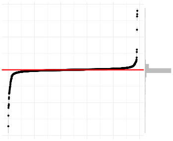

NOTE: figure/graphic rendered as an image from the PDF; its content is not machine-readable text. Caption (if any) follows as the next block.

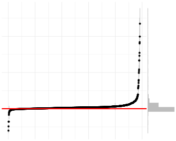

NOTE: figure/graphic rendered as an image from the PDF; its content is not machine-readable text. Caption (if any) follows as the next block.

−2

−1

0

1

2

0 250 500 750 1000 1250 Game

Elasticities of YouTube videos on game purchase

(a) Game purchase

0

1

2

0 250 500 750 1000 1250 Game

Elasticities of YouTube videos on game usage

(b) Game usage

**Notes:** Figure 8a and 8b plot the elasticities of YouTube videos on game purchase and usage respectively for individual games based on our estimated coefficients for game and video characteristics from 6. Grey lines denote 95% confidence intervals. The histogram of the point estimates are shown on the vertical margin.

Table 15: Matrix of purchase and usage effect of YouTube videos for different games

|  |  |  | Usage Substitutes Complements Significant Insignificant Insignificant Significant |  |  |  |
| --- | --- | --- | --- | --- | --- | --- |
|  |  |  |  |  | Complements |  |
|  |  |  |  | Insignificant | Insignificant Sig | nificant |
| Purchase | Substitutes | Significant | 138% . | 081% . | 106% 4 . | 005% . |
|  |  | Insignificant | 041% . | 024% . | 024% . | 463% . |
|  | Complements | Insignificant | 057% . | 049% . | 032% . | 471% . |
|  |  | Significant | 1015% . | 154% . | 227% 3 . | 111% . |

NOTE: table converted from PDF layout to HTML text; cell boundaries are reconstructed. See PDF if exact alignment matters.

Complements Insignificant 0.57% 0.49% 0.32% 4.71% Significant 10.15% 1.54% 2.27% 31.11% **Notes:** The percentage of games with positive or negative effects with significance from one YouTube video based on estimates from table 6.

60

Electronic copy available at: https://ssrn.com/abstract=3884038